# Supplementary Material

Sam Passmore and Fiona Jordan

01/08/2018

# 1 Data

## 1.1 Kinship and social structure

All data was extracted from the D-PLACE Ethnographic atlas [github repository](https://github.com/D-PLACE/dplace-data). Counts of the number of societies used for the signal and ancestral state analyses for each languages family are in table S1. Question and variable codes are displayed below in table S2. Due to the nature of the analysis, all variables are binary coded. The numbers in the value columns indicate the criteria for a society to have the terminology or social structure coded as present (i.e. 1). For details on what each code indicates, refer to the Ethnographic Atlas codebook or the [D-PLACE github repository](https://github.com/D-PLACE/dplace-data/blob/master/datasets/EA/codes.csv).

Table S1: Count of societies in signal test and ancestral state analyses, by language family

|  | Count |
| --- | --- |
| Austronesian | 85 |
| Bantu | 69 |
| Uto-Aztecan | 22 |

Table S2: Data coding taken from D-PLACE and Co-evolutionary analyses data counts

| terminology | question | value | social structure | question | value | AN counts | BT counts | UA counts |
| --- | --- | --- | --- | --- | --- | --- | --- | --- |
| Crow | 27 | 1 | matrilineal | 43 | 3 | 85 | 69 |  |
| Crow | 27 | 1 | high.polygyny | 9 | 3,4,5,6 | 80 |  |  |
| Crow | 27 | 1 | polygyny | 9 | 2,3,4,5,6 | 80 |  |  |
| Crow | 27 | 1 | matri.anvunclocalresidence | 10 | 1,5,9 | 84 | 69 |  |
| Crow | 27 | 1 | uni.localresidence | 10 | 1,5,8,9,10 | 84 | 69 |  |
| Eskimo | 27 | 3 | bi.linealdescent | 43 | 2,5,7 | 85 |  |  |
| Eskimo | 27 | 3 | uni.linealdescent | 43 | 1,3,4 | 85 |  |  |
| Eskimo | 27 | 3 | absenceofcousinmarriage.permitted | 25 | 10,11,15 | 79 |  |  |
| Eskimo | 27 | 3 | absenceofcousinmarriage.preference | 23 | 7,8,11,12 | 79 |  |  |
| Eskimo | 27 | 3 | monogamy | 9 | 1 | 80 |  |  |
| Eskimo | 27 | 3 | neo.localresidence | 10 | 6 | 84 |  |  |
| Eskimo | 27 | 3 | nuclear.families | 8 | 1,2 | 83 |  |  |
| Hawaiian | 27 | 4 | bi.linealdescent | 43 | 2,5,7 | 85 | 69 | 23 |
| Hawaiian | 27 | 4 | bi.localextendedfamily | 8 | 6,7,8 | 83 | 69 | 22 |
| Hawaiian | 27 | 4 | absenceofcousinmarriage.permitted | 25 | 10,11,15 | 79 | 66 | 19 |
| Hawaiian | 27 | 4 | absenceofcousinmarriage.preference | 23 | 7,8,11,12 | 79 | 66 | 19 |
| Hawaiian | 27 | 4 | bi.localresidence | 10 | 2,11,12 | 84 | 69 | 22 |
| Iroquois | 27 | 5 | exogamy.unilineal.descent | 15 | 4 | 78 | 62 | 19 |
| Iroquois | 27 | 5 | uni.linealdescent | 43 | 1,3,4 | 85 | 69 | 23 |
| Iroquois | 27 | 5 | cross.cousinmarriage.permitted | 25 | 1,6,9 | 79 | 66 | 19 |
| Iroquois | 27 | 5 | cross.cousinmarriage.preferred | 23 | 1,2,3,5,6,8,12,13,14 | 79 | 66 | 19 |
| Iroquois | 27 | 5 | high.polygyny | 9 | 3,4,5,6 | 80 |  | 22 |
| Iroquois | 27 | 5 | polygyny | 9 | 2,3,4,5,6 | 80 |  |  |
| Iroquois | 27 | 5 | matri.anvunclocalresidence | 10 | 1,5,9 | 84 | 69 | 22 |
| Iroquois | 27 | 5 | uni.localresidence | 10 | 1,5,8,9,10 | 84 | 69 | 22 |
| Omaha | 27 | 6 | patrilineal | 43 | 1 |  | 69 |  |
| Omaha | 27 | 6 | matri.anvunclocalresidence | 10 | 1,5,9 |  | 69 |  |
| Omaha | 27 | 6 | uni.localresidence | 10 | 1,5,8,9,10 |  | 69 |  |

### 1.1.1 Co-evolutionary hypotheses and references

Table S3: hypotheses with quotes, references and page numbers

| terminology | hypotheses | quote | justification | reference | also.seen |
| --- | --- | --- | --- | --- | --- |
| Crow | High polygyny | “Non-sororal polygyny tends to be associated with kinship terminology of the bifurcate collateral type” | Polygyny spatially separates lineal relatives, meaning women are surrounded by co-wives and not sisters, and children by half-siblings and not parallel cousins, which prevents merging of lineal kinshi… | Murdock, G. P. (1949). Social structure (Vol. xvii). Oxford, England: Macmillan. |  |
| Crow | Matri-avunculocal residence | “Crow systems should occur more frequency in societies which are avunculocal …” | Avunculoval residence means married couples move to live with the husband’s mother’s brother and are spatially closer to maternal kin, meaning there is more pressure to specifically identify maternal … | Eyde, D. B., & Postal, P. M. (1961). Avunculocal and Incest: The Development of Unilateral Cross-Cousin Marriage and Crow-Omaha Kinship Systems. American Anthropologist, 63(4), 747–771. |  |
| Crow | Matrilineal | “The tables show a strong correlation between Omaha terms and patrilineal unilineal descent groups and between Crow terms and matrilineal unilineal descent groups” | A matrilineal descent system imposes a higher social status (social differential) on maternal kin, and therefore the need to distinguish maternal kin over paternal. This allows the grouping of paterna… | Goody, J. (1970). Cousin Terms. Southwestern Journal of Anthropology, 26(2), 125–142. | Hornborg (1998) Serial Redundancy in Amazonian Social Structure: Is there a method for Postructuralist comparison? In Transformations of Kinship. Smithsonian Instituional Press |
| Crow | Polygyny | “Non-sororal polygyny tends to be associated with kinship terminology of the bifurcate collateral type” | Polygyny spatially separates lineal relatives, meaning women are surrounded by co-wives and not sisters, and children by half-siblings and not parallel cousins, which prevents merging of lineal kinshi… | Murdock, G. P. (1949). Social structure (Vol. xvii). Oxford, England: Macmillan. |  |
| Crow | Uni-local residence | “In the presence of patrilocal, matri-local or avunculocal residence, separate terms tend to be applied to relatives of the same generation who are linked to ego through connecting relatives of a diff… | A unilocal residence rule brings into proximity a group of relatives linked under one line of decent. This rule acts as a social differential to support bifurcation of cousin terms. | Murdock, G. P. (1949). Social structure (Vol. xvii). Oxford, England: Macmillan. |  |
| Eskimo | Absence of CM permitted | “Prohibition on cousins vary [in Eskimo-types], but as one might expect, are inevitably bilateral” | If all cousins are unmarriagable, there is no social differential and therefore no need to distinguish them | Fox, R. (1967). Kinship and Marriage: An Anthropological Perspective. Cambridge University Press. |  |
| Eskimo | Absence of CM preference | “Prohibition on cousins vary [in Eskimo-types], but as one might expect, are inevitably bilateral” | If all cousins are unmarriagable, there is no social differential and therefore no need to distinguish them | Fox, R. (1967). Kinship and Marriage: An Anthropological Perspective. Cambridge University Press. |  |
| Eskimo | Bi-lineal descent | “…there is a distinct association of Eskimo terms with bilateral [descent] systems” | When terms differentiate between full siblings and cousins when they are socially differentiated (in this case it is proposed to reflect direct patterns of inheritance). | Goody, J. (1970). Cousin Terms. Southwestern Journal of Anthropology, 26(2), 125–142. |  |
| Eskimo | Monogamy | “The following variables are dependent upon diverging devolution (transmission of property to both males and females): greater control of women’s’ marriage (prohibition of premarital sex, endogamy, fa… | When there is a social focus on the monogamous nuclear family, there is a need to distinguish children and siblings from other closely related nuclear families. | Goody, J., Irving, B., & Tahany, N. (1970). Causal Inferences Concerning Inheritance and Property. Human Relations, 24, 295–314. |  |
| Eskimo | Neo-local residence | “Neolocal residence tends to be associated with kinship terminology of the lineal type.” | Neo-local residence results in the spatial seperation of lineal relatives from all colateral relative, and emphasises the residential group | Murdock, G. P. (1949). Social structure (Vol. xvii). Oxford, England: Macmillan. |  |
| Eskimo | Nuclear families | “In the absence of clans and polygamous and extended families, the isolated nuclear family tends to be associated with kinship terminology of the lineal type.” | The isolation of the nuclear family operates as a social differenetial and favours separate terms for the lineal and colateral kin. | Murdock, G. P. (1949). Social structure (Vol. xvii). Oxford, England: Macmillan. |  |
| Hawaiian | Absence of CM permitted | “Hawaiian [kin] terms … are associated with the prohibition on [cross] cousin marriage” | If all cousins are unmarriagable, there is no social differential and therefore no need to distinguish them | Goody, J. (1970). Cousin Terms. Southwestern Journal of Anthropology, 26(2), 125–142. |  |
| Hawaiian | Absence of CM preference | “Hawaiian [kin] terms … are associated with the prohibition on [cross] cousin marriage” | If all cousins are unmarriagable, there is no social differential and therefore no need to distinguish them | Goody, J. (1970). Cousin Terms. Southwestern Journal of Anthropology, 26(2), 125–142. |  |
| Hawaiian | Bi-lineal descent | “Bilateral kindreds tend to be associated with kinship terminology of the generation type” | If there is no social differential between maternal or paternal relatives, nor is there a pressure to distinguish nuclear family from other kin, then there is no pressure to linguistically distinguish… | Murdock, G. P. (1949). Social structure (Vol. xvii). Oxford, England: Macmillan. |  |
| Hawaiian | Bi-local extended family | “The several types of extended family … depend upon the prevailing rule of residence and exert the influences upon kinship nomenclature already set forth in Theorems 6 and 11” | Extended families increase social participation and interdependence within society and there fore emphasise the effect of bilineal descent. | Murdock, G. P. (1949). Social structure (Vol. xvii). Oxford, England: Macmillan. |  |
| Hawaiian | Bi-local residence | “Bilocal residence tends to be associated with kinship terminology of the generation type” | Bilineal decent brings together some lineal kin, and some colateral kin, some through men and some though women. All these groups combined are then all overridden and individuals are treated equally. | Murdock, G. P. (1949). Social structure (Vol. xvii). Oxford, England: Macmillan. |  |
| Iroquois | Cross CM permitted | “Iroquois [kin] terms … are associated with preferred cross-cousin marriage” | If cousin marriage is allowed (or preferred) in some but not all cousins, there is a pressure to linguistically distinguish those who are marriagable from those who are not. | Goody, J. (1970). Cousin Terms. Southwestern Journal of Anthropology, 26(2), 125–142. |  |
| Iroquois | Cross CM preferred | “Iroquois [kin] terms … are associated with preferred cross-cousin marriage” | If cousin marriage is allowed (or preferred) in some but not all cousins, there is a pressure to linguistically distinguish those who are marriagable from those who are not. | Goody, J. (1970). Cousin Terms. Southwestern Journal of Anthropology, 26(2), 125–142. |  |
| Iroquois | Exogamy & unilineal descent | “In the presence of exogamous matrilineal or patrilineal lineages, sibs, phratries, or moieties, terms for lineal relatives tend to be extended, within the same sex and generation, to collateral kinsm… | Kin that are members of the same exogamous unilinear group are socially equalized with colateral kin, and are therefore terms are merged. | Murdock, G. P. (1949). Social structure (Vol. xvii). Oxford, England: Macmillan. |  |
| Iroquois | High polygyny | “Non-sororal polygyny tends to be associated with kinship terminology of the bifurcate collateral type” | Polygyny spatially separates lineal relatives, meaning women are surrounded by co-wives and not sisters, and children by half-siblings and not parallel cousins, which prevents merging of lineal kinshi… | Murdock, G. P. (1949). Social structure (Vol. xvii). Oxford, England: Macmillan. |  |
| Iroquois | Matri-avunculocal residence | “Matrilocal and avunculocal residence tend to be associated with kinship terminology of the bifurcate merging type” | Avunculocal residences aligns relatives so that the distinction of collaterality is minimized and there is a tendence to extend kinship terms from lineal to collateral co-residing relatives. | Murdock, G. P. (1949). Social structure (Vol. xvii). Oxford, England: Macmillan. |  |
| Iroquois | Polygyny | “Non-sororal polygyny tends to be associated with kinship terminology of the bifurcate collateral type” | Polygyny spatially separates lineal relatives, meaning women are surrounded by co-wives and not sisters, and children by half-siblings and not parallel cousins, which prevents merging of lineal kinshi… | Murdock, G. P. (1949). Social structure (Vol. xvii). Oxford, England: Macmillan. |  |
| Iroquois | Uni-lineal descent | “The classic but erroneous anthropological view concerning the nature of the ‘Iroquois type’ of kinship system … is that this kind of system classifies kin by membership in unilineal descent groups” | ? | Lounsbury, F. G. (1964). The structural analysis of kinship semantics. Mouton. |  |
| Iroquois | Uni-local residence | “In the presence of patrilocal, matri-local or avunculocal residence, separate terms tend to be applied to relatives of the same generation who are linked to ego through connecting relatives of a diff… | A uni-local residence rule brings into proximity a group of relatives linked under one line of decent. This rule acts as a social differential to support bifurcation of cousin terms. | Murdock, G. P. (1949). Social structure (Vol. xvii). Oxford, England: Macmillan. |  |
| Omaha | High polygyny | “Non-sororal polygyny tends to be associated with kinship terminology of the bifurcate collateral type” | Polygyny spatially separates lineal relatives, meaning women are surrounded by co-wives and not sisters, and children by half-siblings and not parallel cousins, which prevents merging of lineal kinshi… | Murdock, G. P. (1949). Social structure (Vol. xvii). Oxford, England: Macmillan. |  |
| Omaha | Matri-avunculocal residence | “Matrilocal and avunculocal residence tend to be associated with kinship terminology of the bifurcate merging type” | Avunculocal residences aligns relatives so that the distinction of collaterality is minimized and there is a tendence to extend kinship terms from lineal to collateral co-residing relatives. | Murdock, G. P. (1949). Social structure (Vol. xvii). Oxford, England: Macmillan. |  |
| Omaha | Patrilineal | “The tables show a strong correlation between Omaha terms and patrilineal unilineal descent groups and between Crow terms and matrilineal unilineal descent groups” | Patrilineal descent acts as a social differential between maternal and paternal kin, allowing more terminological distinction between patrilineal relatives, and grouping of matrilineal relatives. | Goody, J. (1970). Cousin Terms. Southwestern Journal of Anthropology, 26(2), 125–142. | Hornborg (1998) Serial Redundancy in Amazonian Social Structure: Is there a method for Postructuralist comparison? In Transformations of Kinship. Smithsonian Instituional Press |
| Omaha | Polygyny | “Non-sororal polygyny tends to be associated with kinship terminology of the bifurcate collateral type” | Polygyny spatially separates lineal relatives, meaning women are surrounded by co-wives and not sisters, and children by half-siblings and not parallel cousins, which prevents merging of lineal kinshi… | Murdock, G. P. (1949). Social structure (Vol. xvii). Oxford, England: Macmillan. |  |
| Omaha | Uni-local residence | “In the presence of patrilocal, matri-local or avunculocal residence, separate terms tend to be applied to relatives of the same generation who are linked to ego through connecting relatives of a diff… | A uni-local residence rule brings into proximity a group of relatives linked under one line of decent. This rule acts as a social differential to support bifurcation of cousin terms. | Murdock, G. P. (1949). Social structure (Vol. xvii). Oxford, England: Macmillan. |  |

## 1.2 Phylogenies

We tested hypotheses across three languages families, where data allowed. This was the Austronesian, Bantu, and Uto-Aztecan language phylogenies (@gray2009, @grollemund2015bantu, @Levinson_Greenhill_Gray_Dunn_2011). All language to phylogeny pairings were taken from decisions made in @kirby2016d. In Austronesian, we sub-sampled 1000 phylogenies from a posterior sample of 4199 phylogenies. Austronesian phylogenies were estimated through linguistic data and supported by genetic evidence, and archaeological records. Detailed methods can be found in @gray2009. Trees were pruned from the original sample of 400 languages, to 80 languages based on data availability. In Bantu, we sampled 1000 from a posterior sample of 2000 phylogenies developed in @grollemund2015bantu. These trees were built using linguistic data and calibrated using the archaeological record. Trees were pruned from the original sample of 425 languages, to 69 languages based on data availability. In Uto-Aztecan, we sampled 1000 phylogenies from a posterior of 10,000 phylogenies modeled by @Levinson_Greenhill_Gray_Dunn_2011. This posterior was built using linguistic data. Trees were pruned from the original sample of 34 languages, to 19 based on data availability.

# 2 Signal tests

The code for all signal tests can be found in file `analysis/signal-tests.R`. This file comes with helper functions `analysis/signal-functions` and `analysis/mantel-functions` for the D-statistic and Mantel tests respectively.

Table S4: Signal tests for each terminology within each langauge family. Columns 2 and 3 indicate the presence and absence of a terminology. Columns 4 to 6 are outputs from the D-statistic test. Columns 7 to 21 are output from Mantel tests. P-values and bonferonni corrected values shown

| Terminology | Absent | Present | D-statistic D | D-statistic Prob. Brownian | D-statistic Prob. Random | Mantel Geography Z-stat | Mantel Geography p-value | Mantel Geography bonf-p | Mantel Log-Geography Z-stat | Mantel Log-Geography p-value | Mantel Log-Geography bonf-p | Mantel Phylogeny Z-stat | Mantel Phylogeny p-value | Mantel Phylogeny bonf-p | Partial Mantel Log-Geo + Phy Statistic | Partial Mantel Log-Geo + Phy p-value | Partial Mantel Log-Geo + Phy bonf-p | Partial Mantel Phy + Log Geo Statistic | Partial Mantel Phy + Log Geo p-value | Partial Mantel Phy + Log Geo bonf-p |
| --- | --- | --- | --- | --- | --- | --- | --- | --- | --- | --- | --- | --- | --- | --- | --- | --- | --- | --- | --- | --- |
| **Austronesian** |  |  |  |  |  |  |  |  |  |  |  |  |  |  |  |  |  |  |  |  |
| Crow | 79 | 6 | -0.115 | 0.603 | 0.036 | 1752616.53 | 0.039 | 0.233 | 3789.807 | 0.400 | 1.000 | 32.773 | 0.028 | 0.167 | 0.012 | 0.368 | 1.000 | -0.116 | 0.977 | 1.000 |
| Eskimo | 71 | 14 | -0.494 | 0.806 | 0.000 | 4905208.29 | 0.219 | 1.000 | 8155.126 | 0.180 | 0.985 | 78.033 | 0.038 | 0.229 | -0.004 | 0.500 | 1.000 | 0.133 | 0.031 | 0.184 |
| Hawaiian | 37 | 48 | 0.661 | 0.054 | 0.081 | 8021595.70 | 0.959 | 1.000 | 14388.168 | 0.854 | 1.000 | 131.969 | 0.596 | 1.000 | -0.001 | 0.446 | 1.000 | -0.010 | 0.665 | 1.000 |
| Iroquois | 70 | 15 | 0.097 | 0.468 | 0.007 | 4216334.11 | 0.032 | 0.190 | 8460.864 | 0.484 | 1.000 | 74.751 | 0.005 | 0.030 | 0.028 | 0.248 | 1.000 | -0.125 | 0.997 | 1.000 |
| Omaha | 84 | 1 | 2.860 | 0.230 | 0.700 | 430380.25 | 0.376 | 1.000 | 702.380 | 0.377 | 1.000 | 6.328 | 0.867 | 1.000 | 0.044 | 0.171 | 0.975 | -0.014 | 0.626 | 1.000 |
| Sudanese | 84 | 1 | -2.063 | 0.714 | 0.171 | 498098.38 | 0.260 | 1.000 | 709.856 | 0.281 | 1.000 | 6.220 | 0.826 | 1.000 | 0.067 | 0.118 | 0.710 | -0.035 | 0.674 | 1.000 |
| **Bantu** |  |  |  |  |  |  |  |  |  |  |  |  |  |  |  |  |  |  |  |  |
| Crow | 65 | 4 | 1.105 | 0.129 | 0.525 | 348598.29 | 0.887 | 1.000 | 1823.446 | 0.857 | 1.000 | 15359.566 | 0.627 | 1.000 | -0.011 | 0.512 | 1.000 | -0.063 | 0.670 | 1.000 |
| Descriptive | 68 | 1 | 2.941 | 0.066 | 0.881 | 93014.64 | 0.783 | 1.000 | 477.297 | 0.900 | 1.000 | 5417.879 | 0.233 | 1.000 | -0.031 | 0.603 | 1.000 | 0.136 | 0.077 | 0.537 |
| Hawaiian | 60 | 9 | 0.405 | 0.297 | 0.083 | 792380.62 | 0.524 | 1.000 | 3835.774 | 0.496 | 1.000 | 35032.624 | 0.542 | 1.000 | 0.031 | 0.284 | 1.000 | 0.040 | 0.288 | 1.000 |
| Iroquois | 25 | 44 | 0.166 | 0.362 | 0.008 | 1636008.46 | 0.023 | 0.159 | 7853.277 | 0.007 | 0.046 | 71119.715 | 0.151 | 0.892 | 0.105 | 0.005 | 0.038 | 0.051 | 0.138 | 0.863 |
| Mixed | 68 | 1 | -2.432 | 0.834 | 0.040 | 116322.82 | 0.320 | 1.000 | 500.446 | 0.290 | 1.000 | 3836.258 | 0.916 | 1.000 | 0.086 | 0.121 | 0.844 | -0.067 | 0.854 | 1.000 |
| Omaha | 61 | 8 | 0.767 | 0.140 | 0.274 | 733279.95 | 0.393 | 1.000 | 3484.320 | 0.309 | 1.000 | 32352.914 | 0.396 | 1.000 | 0.051 | 0.197 | 1.000 | 0.067 | 0.218 | 1.000 |
| Sudanese | 67 | 2 | 1.051 | 0.287 | 0.459 | 169263.56 | 0.718 | 1.000 | 929.736 | 0.623 | 1.000 | 10075.747 | 0.223 | 1.000 | -0.066 | 0.840 | 1.000 | 0.148 | 0.083 | 0.580 |
| **Uto-Aztecan** |  |  |  |  |  |  |  |  |  |  |  |  |  |  |  |  |  |  |  |  |
| Crow | 21 | 1 | 0.243 | 0.419 | 0.462 | 13195.12 | 0.365 | 1.000 | 132.056 | 0.998 | 1.000 | 0.025 | 0.659 | 0.990 | -0.022 | 0.484 | 1.000 | 0.060 | 0.341 | 0.935 |
| Eskimo | 21 | 1 | 3.253 | 0.216 | 0.679 | 14128.24 | 0.818 | 1.000 | 133.048 | 0.909 | 1.000 | 0.026 | 0.504 | 0.974 | -0.003 | 0.355 | 1.000 | 0.087 | 0.255 | 0.827 |
| Hawaiian | 6 | 16 | -0.600 | 0.798 | 0.004 | 70096.07 | 0.259 | 0.980 | 606.534 | 0.596 | 1.000 | 0.114 | 0.136 | 0.545 | -0.035 | 0.604 | 1.000 | 0.145 | 0.073 | 0.291 |
| Iroquois | 18 | 4 | -2.343 | 0.985 | 0.000 | 54649.14 | 0.881 | 1.000 | 457.499 | 0.973 | 1.000 | 0.086 | 0.235 | 0.840 | 0.001 | 0.438 | 1.000 | 0.134 | 0.120 | 0.479 |

# 3 Ancestral state

## 3.1 MCMC review

Ancestral state inference allows us to estimate the probability of a particular terminology at the root of each language phylogeny, as well as estimating the patterns of change between each state. We perform Bayesian reversible-jump MCMC ancestral state inference kinship terminologies using BayesTraits V 3.0 Multistate (Pagel and Meade 2017). Multistate uses a posterior of phylogenies to estimate the probability of each terminology present in the taxa at the phylogeny root, and an estimation of the rate (Q) matrix. The reversible-jump approach searches the model space for an optimal solution by dynamically setting some rate parameters (i.e. transitions from one state to another) to zero. This results in searching the model space where we are confident transition rates are non-zero. The Q matrix shows the likelihood of changing from any state to any other. MCMC chains were run for 10<sup>9</sup> iterations, sampling every 50,000 iterations with a burn-in of 10,000 iterations, to give a posterior sample of 20,000. Each analysis ran three times to test consistent MCMC convergence using the Gelman-Rubin diagnostic (Gelman and Rubin 1992). Due to uncertainty in the inference of the Bantu ancestral state, each terminology present in the phylogeny was ‘fossilized’ as the root to estimate likelihoods. Effectively, this forces the algorithm to build a model given a particular ancestral state and given the contemporary data. We can then compare the model fit across each constrained model. We calculate pairwise Bayes factors (BF) to assess the evidence for each response. BF < 3 indicates weak evidence, >3 positive evidence, and >10 very strong evidence. This is shown in section 3.1.1.

### 3.1.1 Fossilized Bantu

#### 3.1.1.1 MCMC Review

We fossilize the ancestral state for each possible terminology within Bantu in an attempt to determine the most plausible ancestral state. Below are the MCMC diagnostics for these models and the result with comparisons to an Iroquoian fossilized ancestral state.

Table S9: Marginal log-likelihood for three runs of each fossilized terminology in Bantu

|  | Crow | Descriptive | Hawaiian | Iroquois | Mixed | Omaha | Sudanese |
| --- | --- | --- | --- | --- | --- | --- | --- |
| 1 | 93.867 | 94.056 | 92.303 | 91.562 | 94.748 | 94.915 | 93.454 |
| 2 | 92.828 | 95.856 | 93.706 | 90.160 | 93.739 | 93.824 | 94.241 |
| 3 | 92.440 | 94.463 | 91.300 | 91.131 | 94.466 | 92.978 | 93.329 |
| Mean | 93.041 | 94.786 | 92.426 | 90.947 | 94.316 | 93.899 | 93.673 |

Table S10: Gelman-Rubin tests of MCMC convergence for each each fossilized model

|  | Point est. | Upper C.I. |
| --- | --- | --- |
| Crow | 1 | 1.000 |
| Descriptive | 1 | 1.000 |
| Hawaiian | 1 | 1.001 |
| Iroquois | 1 | 1.000 |
| Mixed | 1 | 1.000 |
| Omaha | 1 | 1.000 |
| Sudanese | 1 | 1.000 |

#### 3.1.1.2 Bayes factor model comparison

Bayes factor calculations show that there is some evidence for a Iroquoian root over a Hawaiian root (BF = 2.957). The table below shows comparisons to the fossilized Iroquois root to all other fossilized roots.

Table S11: Pariwise Bayes factor between Iroquois and all other possible states.

| terminology | Bayes’ Factor |
| --- | --- |
| Crow | 4.188 |
| Descriptive | 7.677 |
| Hawaiian | 2.957 |
| Iroquois | 0.000 |
| Mixed | 6.737 |
| Omaha | 5.904 |
| Sudanese | 5.452 |

## 3.2 PMP in Austronesia

Here we reconstruct the PMP state in Austronesian using the RecNode command in BayesTraits. All other settings remain the same as the Austronesian model.

Table S12: Ancestral state for PMP

|  | Probability |
| --- | --- |
| RecNode P(1) | 0.020 |
| RecNode P(3) | 0.897 |
| RecNode P(4) | 0.004 |
| RecNode P(5) | 0.006 |
| RecNode P(6) | 0.026 |
| RecNode P(7) | 0.046 |

## 3.4 Guillon and Mace comparison

Previous research performed by Guillon and Mace, using similar methods, found support for a Hawaiian root, with some evidence of an Iroquoian root within the Bantu language family. The numerical results for this analysis are not available in the paper. This is the inverse of our result, which found most support for an Iroquoian root, with some support for Hawaiian. This discrepancy is concerning considering the terminological data for both analysis come from d-place. The primary difference between approaches is that here we use a more recently developed phylogeny, and secondarily, Guillon and Mace include missing data, where we exclude it. We re-analysed our data including missing data and found no change in our previous conclusions. Suggesting that the improved phylogeny is driving the change in results. Efforts were made to contact the authors to make more direct comparisons, but with no response.

Table S16: Ancestral state of Bantu with missing data included

|  | probability |
| --- | --- |
| Crow | 0.124 |
| Descriptive | 0.117 |
| Hawaiian | 0.139 |
| Iroquois | 0.259 |
| Omaha | 0.124 |
| Sudanese | 0.119 |
| Mixed | 0.118 |

# 4 Co-evolution tests

## 4.1 MCMC settings

All co-evolutionary analyses was performed in BayesTraits v3.1 using Discrete models [@pagel2006bayesian]. For all models we used an Reversible Jump MCMC approach, and tested an independent and dependent model of evolution. In an independent model, a trait can change, regardless of the state of the other trait. In a dependent model, a trait change is dependent on the state of the second trait. If co-evolution has occurred, the data should fit a dependent model better than it fits an independent model. We test this using Bayes Factors and the same guides as described previously in the paper and SM. Analyses were run between 10,010,000 and 65,000,000 iterations, with burn-ins ranging between 10,000 and 55,000,000, and sampling every 1000 iterations. The results is a posterior of 10,000 iterations, approximately 10 iterations per tree per hypotheses. A stepping stone sampler was used to estimate the marginal likelihood. We used 100 stones sampled every 1,000 iterations. For details of the prior and other settings for each hypotheses, see the table below.

Table S17: MCMC settings for both dependent and independent analyses

| hypotheses | exponential mean | scaled branch length | iterations | sampling | burn-in | posterior size |
| --- | --- | --- | --- | --- | --- | --- |
| austronesian-crow-high.polygyny | 10 | Yes | 10050000 | 1000 | 50000 | 10000 |
| austronesian-crow-matri.anvunclocalresidence | 10 | Yes | 10050000 | 1000 | 50000 | 10000 |
| austronesian-crow-matrilineal | 10 | Yes | 10050000 | 1000 | 50000 | 10000 |
| austronesian-crow-polygyny | 10 | Yes | 10050000 | 1000 | 50000 | 10000 |
| austronesian-crow-matrilocal | 10 | Yes | 10010000 | 1000 | 10000 | 10000 |
| austronesian-crow-strict.matrilocal | 10 | Yes | 10010000 | 1000 | 10000 | 10000 |
| austronesian-crow-uni.localresidence | 10 | Yes | 10010000 | 1000 | 10000 | 10000 |
| austronesian-eskimo-absenceofcousinmarriage.permitted | 10 | Yes | 65000000 | 1000 | 55000000 | 10000 |
| austronesian-eskimo-absenceofcousinmarriage.preference | 10 | Yes | 65000000 | 1000 | 55000000 | 10000 |
| austronesian-eskimo-bi.linealdescent | 10 | Yes | 10010000 | 1000 | 10000 | 10000 |
| austronesian-eskimo-monogamy | 10 | Yes | 10050000 | 1000 | 50000 | 10000 |
| austronesian-eskimo-neo.localresidence | 10 | Yes | 65000000 | 1000 | 55000000 | 10000 |
| austronesian-eskimo-nuclear.families | 10 | Yes | 10010000 | 1000 | 10000 | 10000 |
| austronesian-eskimo-uni.linealdescent | 10 | Yes | 10010000 | 1000 | 10000 | 10000 |
| austronesian-hawaiian-absenceofcousinmarriage.permitted | 10 | Yes | 10050000 | 1000 | 50000 | 10000 |
| austronesian-hawaiian-absenceofcousinmarriage.preference | 10 | Yes | 10010000 | 1000 | 10000 | 10000 |
| austronesian-hawaiian-bi.linealdescent | 10 | Yes | 10010000 | 1000 | 10000 | 10000 |
| austronesian-hawaiian-bi.localextendedfamily | 10 | Yes | 10010000 | 1000 | 10000 | 10000 |
| austronesian-hawaiian-bi.localresidence | 10 | Yes | 10050000 | 1000 | 50000 | 10000 |
| austronesian-iroquois-cross.cousinmarriage.permitted | 10 | Yes | 10010000 | 1000 | 10000 | 10000 |
| austronesian-iroquois-cross.cousinmarriage.preferred | 10 | Yes | 10010000 | 1000 | 10000 | 10000 |
| austronesian-iroquois-exogamy.unilineal.descent | 10 | Yes | 10010000 | 1000 | 10000 | 10000 |
| austronesian-iroquois-high.polygyny | 10 | Yes | 10010000 | 1000 | 10000 | 10000 |
| austronesian-iroquois-matri.anvunclocalresidence | 10 | Yes | 10010000 | 1000 | 10000 | 10000 |
| austronesian-iroquois-polygyny | 10 | Yes | 10010000 | 1000 | 10000 | 10000 |
| austronesian-iroquois-uni.linealdescent | 10 | Yes | 10010000 | 1000 | 10000 | 10000 |
| austronesian-iroquois-uni.localresidence | 10 | Yes | 10050000 | 1000 | 50000 | 10000 |
| bantu-crow-matri.anvunclocalresidence | 10 | Yes | 10010000 | 1000 | 10000 | 10000 |
| bantu-crow-matrilineal | 10 | Yes | 10010000 | 1000 | 10000 | 10000 |
| bantu-crow-matrilocal | 10 | Yes | 10050000 | 1000 | 50000 | 10000 |
| bantu-crow-strict.matrilocal | 10 | Yes | 10050000 | 1000 | 50000 | 10000 |
| bantu-crow-uni.localresidence | 10 | Yes | 10010000 | 1000 | 10000 | 10000 |
| bantu-hawaiian-absenceofcousinmarriage.permitted | 10 | Yes | 10010000 | 1000 | 10000 | 10000 |
| bantu-hawaiian-absenceofcousinmarriage.preference | 10 | Yes | 10010000 | 1000 | 10000 | 10000 |
| bantu-hawaiian-bi.linealdescent | 10 | Yes | 10010000 | 1000 | 10000 | 10000 |
| bantu-hawaiian-bi.localextendedfamily | 10 | Yes | 10010000 | 1000 | 10000 | 10000 |
| bantu-hawaiian-bi.localresidence | 10 | Yes | 10010000 | 1000 | 10000 | 10000 |
| bantu-iroquois-cross.cousinmarriage.permitted | 10 | Yes | 10010000 | 1000 | 10000 | 10000 |
| bantu-iroquois-cross.cousinmarriage.preferred | 10 | Yes | 10010000 | 1000 | 10000 | 10000 |
| bantu-iroquois-exogamy.unilineal.descent | 10 | Yes | 10010000 | 1000 | 10000 | 10000 |
| bantu-iroquois-matri.anvunclocalresidence | 10 | Yes | 10010000 | 1000 | 10000 | 10000 |
| bantu-iroquois-uni.linealdescent | 10 | Yes | 10010000 | 1000 | 10000 | 10000 |
| bantu-iroquois-uni.localresidence | 10 | Yes | 10010000 | 1000 | 10000 | 10000 |
| bantu-omaha-matri.anvunclocalresidence | 10 | Yes | 10010000 | 1000 | 10000 | 10000 |
| bantu-omaha-patrilineal | 10 | Yes | 10010000 | 1000 | 10000 | 10000 |
| bantu-omaha-patrilocal | 10 | Yes | 10010000 | 1000 | 10000 | 10000 |
| bantu-omaha-strict.patrilocal | 10 | Yes | 10010000 | 1000 | 10000 | 10000 |
| bantu-omaha-uni.localresidence | 10 | Yes | 10010000 | 1000 | 10000 | 10000 |
| uto-hawaiian-absenceofcousinmarriage.permitted | 10 | Yes | 10010000 | 1000 | 10000 | 10000 |
| uto-hawaiian-absenceofcousinmarriage.preference | 10 | Yes | 10010000 | 1000 | 10000 | 10000 |
| uto-hawaiian-bi.linealdescent | 10 | Yes | 10010000 | 1000 | 10000 | 10000 |
| uto-hawaiian-bi.localextendedfamily | 10 | Yes | 10010000 | 1000 | 10000 | 10000 |
| uto-hawaiian-bi.localresidence | 10 | Yes | 10010000 | 1000 | 10000 | 10000 |
| uto-iroquois-cross.cousinmarriage.permitted | 10 | Yes | 10010000 | 1000 | 10000 | 10000 |
| uto-iroquois-cross.cousinmarriage.preferred | 10 | Yes | 10010000 | 1000 | 10000 | 10000 |
| uto-iroquois-exogamy.unilineal.descent | 10 | Yes | 10010000 | 1000 | 10000 | 10000 |
| uto-iroquois-high.polygyny | 10 | Yes | 10010000 | 1000 | 10000 | 10000 |
| uto-iroquois-matri.anvunclocalresidence | 10 | Yes | 10010000 | 1000 | 10000 | 10000 |
| uto-iroquois-uni.linealdescent | 10 | Yes | 10010000 | 1000 | 10000 | 10000 |
| uto-iroquois-uni.localresidence | 10 | Yes | 10010000 | 1000 | 10000 | 10000 |

## 4.2 MCMC review and Bayes Factors

Here we show the results of MCMC chains and respective tests. The first table for each hypotheses is a review of the MCMC chains. Each row shows the marginal log-likelihood and averaged transition rates for the dependent and independent models for a single chain. There are three MCMC chains run for each hypotheses to ensure the model is reaching the same conclusion each time. The penultimate row shows the mean across the three runs. The final row tests which model was more appropriate for the data. We calculate a Bayes-factor, which compares the log marginal likelihood between the dependent and independent models, as explained in @pagel2006bayesian. A Bayes Factor greater than ten indicates strong support, greater than three positive support and less than three no support.

A second table shows the results of a Gelman-Rubin diagnostic testing, to test for any significant differences between chains [@gelman1992single]. A value of 1 indicates no difference, and a rule of thumb suggests point-estimates of less than 1.1 indicate negligible differences between chains.

Some extra analyses are also shown here that are not seen in table 1. These are matrilocal and patrilocal hypotheses and matrilocal.strict and patrilocal.strict. The strict hypothesis exclude anything but societies classified as patrilocal or matrilocal. In the main text we discuss the differences between including virilocality and uxorilocality under each of these hypotheses, there are represented in the ‘not strict’ hypothesis.

Table S19: Austronesian : Crow Matri.anvunclocalresidence

| run | Dependent MLL | Dependent q12 | Dependent q13 | Dependent q21 | Dependent q24 | Dependent q31 | Dependent q34 | Dependent q42 | Dependent q43 | Independent MLL | Independent alpha1 | Independent beta1 | Independent alpha2 | Independent beta2 |
| --- | --- | --- | --- | --- | --- | --- | --- | --- | --- | --- | --- | --- | --- | --- |
| 1 | 54.425 | 1.001 | 0.363 | 6.615 | 8.88 | 12.392 | 10.208 | 17.431 | 4.755 | 59.923 | 1.627 | 21.93 | 1.185 | 5.659 |
| 2 | 54.6 | 1.005 | 0.368 | 6.664 | 8.882 | 12.318 | 10.273 | 17.728 | 4.562 | 59.87 | 1.609 | 22.061 | 1.167 | 5.661 |
| 3 | 54.523 | 1.006 | 0.364 | 6.676 | 8.975 | 12.258 | 10.347 | 17.619 | 4.556 | 59.873 | 1.62 | 21.993 | 1.161 | 5.645 |
| Mean | 54.516 | 1.004 | 0.365 | 6.652 | 8.912 | 12.323 | 10.276 | 17.593 | 4.624 | 59.889 | 1.619 | 21.995 | 1.171 | 5.655 |
| BF | 10.996 |  |  |  |  |  |  |  |  |  |  |  |  |  |

Gelman-Rubin MCMC chain diagnostic test

|  | Point est. | Upper C.I. |
| --- | --- | --- |
| Dependent | 1 | 1 |
| Independent | 1 | 1 |

Table S20: Austronesian : Crow Matrilineal

| run | Dependent MLL | Dependent q12 | Dependent q13 | Dependent q21 | Dependent q24 | Dependent q31 | Dependent q34 | Dependent q42 | Dependent q43 | Independent MLL | Independent alpha1 | Independent beta1 | Independent alpha2 | Independent beta2 |
| --- | --- | --- | --- | --- | --- | --- | --- | --- | --- | --- | --- | --- | --- | --- |
| 1 | 56.179 | 0.75 | 0.325 | 5.111 | 8.573 | 12.419 | 11.202 | 17.916 | 8.893 | 61.268 | 1.606 | 21.764 | 1.008 | 6.244 |
| 2 | 55.993 | 0.753 | 0.321 | 5.149 | 8.573 | 12.284 | 11.428 | 17.707 | 8.854 | 61.198 | 1.585 | 21.953 | 1.019 | 6.408 |
| 3 | 56.23 | 0.752 | 0.324 | 5.048 | 8.637 | 12.227 | 11.499 | 18.073 | 8.846 | 61.059 | 1.594 | 21.742 | 1.005 | 6.27 |
| Mean | 56.134 | 0.752 | 0.323 | 5.103 | 8.594 | 12.31 | 11.376 | 17.899 | 8.864 | 61.175 | 1.595 | 21.82 | 1.011 | 6.307 |
| BF | 10.179 |  |  |  |  |  |  |  |  |  |  |  |  |  |

Gelman-Rubin MCMC chain diagnostic test

|  | Point est. | Upper C.I. |
| --- | --- | --- |
| Dependent | 1.001 | 1.002 |
| Independent | 1.000 | 1.001 |

Table S21: Austronesian : Crow Polygyny

| run | Dependent MLL | Dependent q12 | Dependent q13 | Dependent q21 | Dependent q24 | Dependent q31 | Dependent q34 | Dependent q42 | Dependent q43 | Independent MLL | Independent alpha1 | Independent beta1 | Independent alpha2 | Independent beta2 |
| --- | --- | --- | --- | --- | --- | --- | --- | --- | --- | --- | --- | --- | --- | --- |
| 1 | 68.655 | 2.704 | 2.446 | 1.487 | 0.936 | 24.306 | 6.911 | 9.755 | 5.047 | 67.511 | 1.671 | 21.339 | 2.645 | 1.582 |
| 2 | 68.755 | 2.727 | 2.488 | 1.508 | 0.935 | 24.25 | 6.976 | 10.088 | 5.033 | 67.527 | 1.666 | 21.339 | 2.59 | 1.582 |
| 3 | 68.604 | 2.655 | 2.473 | 1.499 | 0.913 | 23.958 | 6.946 | 9.748 | 4.884 | 67.604 | 1.663 | 21.321 | 2.638 | 1.583 |
| Mean | 68.671 | 2.695 | 2.469 | 1.498 | 0.928 | 24.171 | 6.944 | 9.864 | 4.988 | 67.547 | 1.667 | 21.333 | 2.624 | 1.582 |
| BF | -2.289 |  |  |  |  |  |  |  |  |  |  |  |  |  |

Gelman-Rubin MCMC chain diagnostic test

|  | Point est. | Upper C.I. |
| --- | --- | --- |
| Dependent | 1 | 1.001 |
| Independent | 1 | 1.000 |

Table S24: Austronesian : Crow Uni.localresidence

| run | Dependent MLL | Dependent q12 | Dependent q13 | Dependent q21 | Dependent q24 | Dependent q31 | Dependent q34 | Dependent q42 | Dependent q43 | Independent MLL | Independent alpha1 | Independent beta1 | Independent alpha2 | Independent beta2 |
| --- | --- | --- | --- | --- | --- | --- | --- | --- | --- | --- | --- | --- | --- | --- |
| 1 | 72.587 | 1.472 | 0.326 | 2.908 | 4.218 | 14.951 | 11.355 | 20.871 | 2.438 | 74.535 | 1.311 | 17.342 | 1.498 | 2.65 |
| 2 | 72.502 | 1.463 | 0.321 | 2.895 | 4.214 | 15.101 | 11.137 | 20.935 | 2.477 | 74.332 | 1.307 | 17.558 | 1.508 | 2.669 |
| 3 | 72.666 | 1.472 | 0.32 | 2.901 | 4.14 | 14.393 | 11.306 | 20.589 | 2.461 | 74.314 | 1.305 | 17.704 | 1.486 | 2.691 |
| Mean | 72.585 | 1.469 | 0.322 | 2.901 | 4.191 | 14.815 | 11.266 | 20.798 | 2.459 | 74.394 | 1.308 | 17.535 | 1.497 | 2.67 |
| BF | 3.896 |  |  |  |  |  |  |  |  |  |  |  |  |  |

Gelman-Rubin MCMC chain diagnostic test

|  | Point est. | Upper C.I. |
| --- | --- | --- |
| Dependent | 1 | 1 |
| Independent | 1 | 1 |

Table S25: Austronesian : Eskimo Absenceofcousinmarriage.permitted

| run | Dependent MLL | Dependent q12 | Dependent q13 | Dependent q21 | Dependent q24 | Dependent q31 | Dependent q34 | Dependent q42 | Dependent q43 | Independent MLL | Independent alpha1 | Independent beta1 | Independent alpha2 | Independent beta2 |
| --- | --- | --- | --- | --- | --- | --- | --- | --- | --- | --- | --- | --- | --- | --- |
| 1 | 79.763 | 15.161 | 1.977 | 3.937 | 0.348 | 5.19 | 7.168 | 3.34 | 5.893 | 79.562 | 0.255 | 3.458 | 14.452 | 5.047 |
| 2 | 79.363 | 15.02 | 1.966 | 3.895 | 0.34 | 5.24 | 7.107 | 3.326 | 5.804 | 79.429 | 0.252 | 3.424 | 14.263 | 4.993 |
| 3 | 79.647 | 14.919 | 2.039 | 3.851 | 0.348 | 5.266 | 7.158 | 3.316 | 5.792 | 79.407 | 0.248 | 3.435 | 14.485 | 5.027 |
| Mean | 79.591 | 15.033 | 1.994 | 3.894 | 0.345 | 5.232 | 7.144 | 3.327 | 5.83 | 79.466 | 0.252 | 3.439 | 14.4 | 5.022 |
| BF | -0.403 |  |  |  |  |  |  |  |  |  |  |  |  |  |

Gelman-Rubin MCMC chain diagnostic test

|  | Point est. | Upper C.I. |
| --- | --- | --- |
| Dependent | 1 | 1.000 |
| Independent | 1 | 1.001 |

Table S26: Austronesian : Eskimo Absenceofcousinmarriage.preference

| run | Dependent MLL | Dependent q12 | Dependent q13 | Dependent q21 | Dependent q24 | Dependent q31 | Dependent q34 | Dependent q42 | Dependent q43 | Independent MLL | Independent alpha1 | Independent beta1 | Independent alpha2 | Independent beta2 |
| --- | --- | --- | --- | --- | --- | --- | --- | --- | --- | --- | --- | --- | --- | --- |
| 1 | 70.982 | 4.304 | 0.37 | 18.765 | 1.097 | 3.256 | 0.933 | 11.573 | 13.262 | 69.919 | 0.26 | 3.423 | 3.656 | 19.635 |
| 2 | 70.922 | 4.359 | 0.374 | 19.159 | 1.124 | 3.234 | 0.946 | 12.145 | 13.246 | 69.887 | 0.263 | 3.471 | 3.717 | 19.853 |
| 3 | 71.328 | 4.345 | 0.391 | 18.755 | 1.134 | 3.191 | 0.938 | 11.917 | 13.473 | 69.947 | 0.254 | 3.429 | 3.742 | 20.068 |
| Mean | 71.077 | 4.336 | 0.378 | 18.893 | 1.118 | 3.227 | 0.939 | 11.878 | 13.327 | 69.918 | 0.259 | 3.441 | 3.705 | 19.852 |
| BF | -2.127 |  |  |  |  |  |  |  |  |  |  |  |  |  |

Gelman-Rubin MCMC chain diagnostic test

|  | Point est. | Upper C.I. |
| --- | --- | --- |
| Dependent | 1 | 1.000 |
| Independent | 1 | 1.001 |

Table S27: Austronesian : Eskimo Bi.linealdescent

| run | Dependent MLL | Dependent q12 | Dependent q13 | Dependent q21 | Dependent q24 | Dependent q31 | Dependent q34 | Dependent q42 | Dependent q43 | Independent MLL | Independent alpha1 | Independent beta1 | Independent alpha2 | Independent beta2 |
| --- | --- | --- | --- | --- | --- | --- | --- | --- | --- | --- | --- | --- | --- | --- |
| 1 | 91.811 | 4.664 | 0.695 | 5.42 | 0.507 | 3.884 | 1.545 | 5.81 | 9.484 | 91.123 | 0.169 | 3.203 | 2.636 | 4.338 |
| 2 | 91.905 | 4.662 | 0.671 | 5.393 | 0.513 | 3.901 | 1.555 | 5.883 | 9.577 | 91.189 | 0.163 | 3.228 | 2.657 | 4.32 |
| 3 | 92.062 | 4.691 | 0.679 | 5.448 | 0.504 | 3.859 | 1.521 | 5.76 | 9.44 | 91.245 | 0.165 | 3.201 | 2.665 | 4.315 |
| Mean | 91.926 | 4.672 | 0.682 | 5.42 | 0.508 | 3.881 | 1.54 | 5.818 | 9.5 | 91.186 | 0.166 | 3.211 | 2.653 | 4.324 |
| BF | -1.378 |  |  |  |  |  |  |  |  |  |  |  |  |  |

Gelman-Rubin MCMC chain diagnostic test

|  | Point est. | Upper C.I. |
| --- | --- | --- |
| Dependent | 1 | 1.001 |
| Independent | 1 | 1.000 |

Table S28: Austronesian : Eskimo Monogamy

| run | Dependent MLL | Dependent q12 | Dependent q13 | Dependent q21 | Dependent q24 | Dependent q31 | Dependent q34 | Dependent q42 | Dependent q43 | Independent MLL | Independent alpha1 | Independent beta1 | Independent alpha2 | Independent beta2 |
| --- | --- | --- | --- | --- | --- | --- | --- | --- | --- | --- | --- | --- | --- | --- |
| 1 | 71.169 | 0.96 | 0.328 | 3.507 | 5.69 | 4.499 | 9.396 | 5.136 | 5.949 | 74.719 | 0.186 | 3.194 | 1.275 | 2.364 |
| 2 | 70.939 | 0.948 | 0.325 | 3.609 | 5.551 | 4.473 | 9.212 | 5.028 | 5.874 | 74.583 | 0.185 | 3.158 | 1.267 | 2.356 |
| 3 | 71.011 | 0.949 | 0.336 | 3.572 | 5.632 | 4.451 | 9.461 | 5.102 | 5.842 | 74.42 | 0.189 | 3.186 | 1.271 | 2.349 |
| Mean | 71.04 | 0.952 | 0.33 | 3.563 | 5.624 | 4.474 | 9.356 | 5.089 | 5.888 | 74.574 | 0.187 | 3.179 | 1.271 | 2.356 |
| BF | 7.099 |  |  |  |  |  |  |  |  |  |  |  |  |  |

Gelman-Rubin MCMC chain diagnostic test

|  | Point est. | Upper C.I. |
| --- | --- | --- |
| Dependent | 1.001 | 1.003 |
| Independent | 1.000 | 1.000 |

Table S29: Austronesian : Eskimo Neo.localresidence

| run | Dependent MLL | Dependent q12 | Dependent q13 | Dependent q21 | Dependent q24 | Dependent q31 | Dependent q34 | Dependent q42 | Dependent q43 | Independent MLL | Independent alpha1 | Independent beta1 | Independent alpha2 | Independent beta2 |
| --- | --- | --- | --- | --- | --- | --- | --- | --- | --- | --- | --- | --- | --- | --- |
| 1 | 52.738 | 0.187 | 0.205 | 8.988 | 10.136 | 3.258 | 4.751 | 6.834 | 11.135 | 56.76 | 0.163 | 3.214 | 0.623 | 7.166 |
| 2 | 52.976 | 0.192 | 0.21 | 8.949 | 10.23 | 3.251 | 4.693 | 6.922 | 10.978 | 56.663 | 0.164 | 3.242 | 0.617 | 7.065 |
| 3 | 52.619 | 0.181 | 0.206 | 8.986 | 10.251 | 3.231 | 4.707 | 6.909 | 11.109 | 56.502 | 0.167 | 3.22 | 0.624 | 7.15 |
| Mean | 52.778 | 0.187 | 0.207 | 8.974 | 10.206 | 3.247 | 4.717 | 6.888 | 11.074 | 56.642 | 0.165 | 3.225 | 0.621 | 7.127 |
| BF | 8.043 |  |  |  |  |  |  |  |  |  |  |  |  |  |

Gelman-Rubin MCMC chain diagnostic test

|  | Point est. | Upper C.I. |
| --- | --- | --- |
| Dependent | 1 | 1.001 |
| Independent | 1 | 1.001 |

Table S30: Austronesian : Eskimo Nuclear.families

| run | Dependent MLL | Dependent q12 | Dependent q13 | Dependent q21 | Dependent q24 | Dependent q31 | Dependent q34 | Dependent q42 | Dependent q43 | Independent MLL | Independent alpha1 | Independent beta1 | Independent alpha2 | Independent beta2 |
| --- | --- | --- | --- | --- | --- | --- | --- | --- | --- | --- | --- | --- | --- | --- |
| 1 | 88.791 | 4.453 | 0.541 | 6.412 | 1.774 | 7.603 | 10.332 | 4.069 | 3.177 | 89.293 | 0.168 | 3.155 | 3.967 | 4.049 |
| 2 | 88.844 | 4.437 | 0.554 | 6.428 | 1.727 | 7.651 | 10.418 | 3.933 | 3.231 | 89.423 | 0.166 | 3.161 | 3.947 | 4.014 |
| 3 | 88.966 | 4.47 | 0.534 | 6.381 | 1.751 | 7.727 | 10.123 | 4.006 | 3.201 | 89.547 | 0.168 | 3.13 | 3.958 | 4.021 |
| Mean | 88.867 | 4.453 | 0.543 | 6.407 | 1.751 | 7.66 | 10.291 | 4.003 | 3.203 | 89.421 | 0.167 | 3.149 | 3.957 | 4.028 |
| BF | 1.005 |  |  |  |  |  |  |  |  |  |  |  |  |  |

Gelman-Rubin MCMC chain diagnostic test

|  | Point est. | Upper C.I. |
| --- | --- | --- |
| Dependent | 1 | 1 |
| Independent | 1 | 1 |

Table S31: Austronesian : Eskimo Uni.linealdescent

| run | Dependent MLL | Dependent q12 | Dependent q13 | Dependent q21 | Dependent q24 | Dependent q31 | Dependent q34 | Dependent q42 | Dependent q43 | Independent MLL | Independent alpha1 | Independent beta1 | Independent alpha2 | Independent beta2 |
| --- | --- | --- | --- | --- | --- | --- | --- | --- | --- | --- | --- | --- | --- | --- |
| 1 | 86.122 | 2.318 | 0.509 | 3.398 | 0.547 | 3.113 | 1.493 | 11.341 | 10.053 | 85.856 | 0.182 | 3.222 | 1.463 | 3.421 |
| 2 | 86.245 | 2.285 | 0.512 | 3.43 | 0.561 | 3.097 | 1.526 | 11.42 | 10.31 | 85.888 | 0.178 | 3.232 | 1.434 | 3.409 |
| 3 | 86.239 | 2.292 | 0.521 | 3.412 | 0.581 | 3.115 | 1.489 | 11.546 | 10.124 | 86.094 | 0.181 | 3.224 | 1.457 | 3.432 |
| Mean | 86.202 | 2.298 | 0.514 | 3.413 | 0.563 | 3.108 | 1.503 | 11.436 | 10.162 | 85.946 | 0.18 | 3.226 | 1.451 | 3.421 |
| BF | -0.531 |  |  |  |  |  |  |  |  |  |  |  |  |  |

Gelman-Rubin MCMC chain diagnostic test

|  | Point est. | Upper C.I. |
| --- | --- | --- |
| Dependent | 1 | 1 |
| Independent | 1 | 1 |

Table S32: Austronesian : Hawaiian Absenceofcousinmarriage.permitted

| run | Dependent MLL | Dependent q12 | Dependent q13 | Dependent q21 | Dependent q24 | Dependent q31 | Dependent q34 | Dependent q42 | Dependent q43 | Independent MLL | Independent alpha1 | Independent beta1 | Independent alpha2 | Independent beta2 |
| --- | --- | --- | --- | --- | --- | --- | --- | --- | --- | --- | --- | --- | --- | --- |
| 1 | 102.827 | 4.674 | 4.321 | 2.333 | 8.86 | 4.524 | 15.484 | 7.557 | 4.612 | 102.627 | 6.731 | 6.065 | 14.792 | 5.12 |
| 2 | 102.483 | 4.789 | 4.366 | 2.331 | 8.965 | 4.534 | 15.336 | 7.614 | 4.608 | 102.612 | 6.782 | 6.1 | 14.697 | 5.143 |
| 3 | 102.652 | 4.818 | 4.319 | 2.367 | 8.764 | 4.561 | 15.403 | 7.461 | 4.694 | 102.653 | 6.744 | 6.103 | 14.501 | 5.049 |
| Mean | 102.654 | 4.76 | 4.335 | 2.344 | 8.863 | 4.54 | 15.408 | 7.544 | 4.638 | 102.631 | 6.752 | 6.089 | 14.663 | 5.104 |
| BF | -0.399 |  |  |  |  |  |  |  |  |  |  |  |  |  |

Gelman-Rubin MCMC chain diagnostic test

|  | Point est. | Upper C.I. |
| --- | --- | --- |
| Dependent | 1 | 1 |
| Independent | 1 | 1 |

Table S33: Austronesian : Hawaiian Absenceofcousinmarriage.preference

| run | Dependent MLL | Dependent q12 | Dependent q13 | Dependent q21 | Dependent q24 | Dependent q31 | Dependent q34 | Dependent q42 | Dependent q43 | Independent MLL | Independent alpha1 | Independent beta1 | Independent alpha2 | Independent beta2 |
| --- | --- | --- | --- | --- | --- | --- | --- | --- | --- | --- | --- | --- | --- | --- |
| 1 | 90.124 | 5.708 | 8.593 | 15.561 | 3.262 | 5.476 | 1.768 | 15.108 | 18.591 | 92.997 | 6.805 | 6.124 | 3.69 | 19.614 |
| 2 | 90.118 | 5.608 | 8.36 | 15.494 | 3.282 | 5.402 | 1.765 | 14.89 | 18.401 | 92.943 | 6.886 | 6.142 | 3.672 | 19.728 |
| 3 | 90.145 | 5.711 | 8.419 | 15.564 | 3.322 | 5.401 | 1.768 | 14.724 | 18.662 | 93.066 | 6.808 | 6.129 | 3.687 | 19.489 |
| Mean | 90.129 | 5.676 | 8.457 | 15.54 | 3.289 | 5.426 | 1.767 | 14.907 | 18.551 | 93.002 | 6.833 | 6.132 | 3.683 | 19.61 |
| BF | 5.747 |  |  |  |  |  |  |  |  |  |  |  |  |  |

Gelman-Rubin MCMC chain diagnostic test

|  | Point est. | Upper C.I. |
| --- | --- | --- |
| Dependent | 1.001 | 1.001 |
| Independent | 1.000 | 1.001 |

Table S34: Austronesian : Hawaiian Bi.linealdescent

| run | Dependent MLL | Dependent q12 | Dependent q13 | Dependent q21 | Dependent q24 | Dependent q31 | Dependent q34 | Dependent q42 | Dependent q43 | Independent MLL | Independent alpha1 | Independent beta1 | Independent alpha2 | Independent beta2 |
| --- | --- | --- | --- | --- | --- | --- | --- | --- | --- | --- | --- | --- | --- | --- |
| 1 | 111.964 | 4.095 | 10.456 | 13.878 | 8.113 | 16.741 | 3.164 | 2.399 | 3.75 | 117.351 | 7.703 | 6.823 | 2.47 | 4.277 |
| 2 | 111.815 | 4.072 | 10.406 | 14.024 | 8.316 | 16.793 | 3.203 | 2.453 | 3.79 | 117.3 | 7.631 | 6.82 | 2.461 | 4.271 |
| 3 | 111.892 | 4.032 | 10.57 | 13.609 | 8.043 | 16.911 | 3.149 | 2.386 | 3.708 | 117.378 | 7.706 | 6.828 | 2.456 | 4.251 |
| Mean | 111.89 | 4.066 | 10.477 | 13.837 | 8.157 | 16.815 | 3.172 | 2.413 | 3.749 | 117.343 | 7.68 | 6.824 | 2.462 | 4.266 |
| BF | 10.774 |  |  |  |  |  |  |  |  |  |  |  |  |  |

Gelman-Rubin MCMC chain diagnostic test

|  | Point est. | Upper C.I. |
| --- | --- | --- |
| Dependent | 1 | 1 |
| Independent | 1 | 1 |

Table S35: Austronesian : Hawaiian Bi.localextendedfamily

| run | Dependent MLL | Dependent q12 | Dependent q13 | Dependent q21 | Dependent q24 | Dependent q31 | Dependent q34 | Dependent q42 | Dependent q43 | Independent MLL | Independent alpha1 | Independent beta1 | Independent alpha2 | Independent beta2 |
| --- | --- | --- | --- | --- | --- | --- | --- | --- | --- | --- | --- | --- | --- | --- |
| 1 | 114.37 | 3.3 | 6.008 | 5.043 | 16.21 | 8.06 | 5.431 | 7.647 | 6.031 | 114.843 | 8.865 | 7.228 | 3.459 | 4.858 |
| 2 | 114.284 | 3.236 | 5.909 | 4.906 | 16.085 | 8.11 | 5.344 | 7.686 | 5.925 | 114.856 | 8.867 | 7.261 | 3.446 | 4.845 |
| 3 | 114.256 | 3.283 | 5.913 | 4.987 | 16.067 | 7.963 | 5.548 | 7.604 | 6.016 | 114.941 | 8.83 | 7.258 | 3.448 | 4.884 |
| Mean | 114.303 | 3.273 | 5.943 | 4.979 | 16.121 | 8.044 | 5.441 | 7.646 | 5.991 | 114.88 | 8.854 | 7.249 | 3.451 | 4.862 |
| BF | 0.947 |  |  |  |  |  |  |  |  |  |  |  |  |  |

Gelman-Rubin MCMC chain diagnostic test

|  | Point est. | Upper C.I. |
| --- | --- | --- |
| Dependent | 1.001 | 1.002 |
| Independent | 1.000 | 1.001 |

Table S36: Austronesian : Hawaiian Bi.localresidence

| run | Dependent MLL | Dependent q12 | Dependent q13 | Dependent q21 | Dependent q24 | Dependent q31 | Dependent q34 | Dependent q42 | Dependent q43 | Independent MLL | Independent alpha1 | Independent beta1 | Independent alpha2 | Independent beta2 |
| --- | --- | --- | --- | --- | --- | --- | --- | --- | --- | --- | --- | --- | --- | --- |
| 1 | 103.925 | 3.156 | 7.405 | 14.707 | 7.214 | 6.896 | 5.493 | 4.662 | 19.958 | 103.049 | 6.883 | 6.076 | 5.015 | 20.523 |
| 2 | 103.725 | 3.21 | 7.415 | 14.719 | 7.055 | 6.913 | 5.37 | 4.674 | 19.585 | 103.09 | 6.896 | 6.052 | 4.954 | 20.272 |
| 3 | 103.821 | 3.182 | 7.459 | 14.661 | 6.812 | 6.914 | 5.477 | 4.663 | 19.914 | 103.124 | 6.903 | 6.105 | 5.003 | 20.455 |
| Mean | 103.824 | 3.183 | 7.426 | 14.696 | 7.027 | 6.908 | 5.447 | 4.666 | 19.819 | 103.088 | 6.894 | 6.078 | 4.991 | 20.417 |
| BF | -1.751 |  |  |  |  |  |  |  |  |  |  |  |  |  |

Gelman-Rubin MCMC chain diagnostic test

|  | Point est. | Upper C.I. |
| --- | --- | --- |
| Dependent | 1 | 1.001 |
| Independent | 1 | 1.001 |

Table S37: Austronesian : Iroquois Cross.cousinmarriage.permitted

| run | Dependent MLL | Dependent q12 | Dependent q13 | Dependent q21 | Dependent q24 | Dependent q31 | Dependent q34 | Dependent q42 | Dependent q43 | Independent MLL | Independent alpha1 | Independent beta1 | Independent alpha2 | Independent beta2 |
| --- | --- | --- | --- | --- | --- | --- | --- | --- | --- | --- | --- | --- | --- | --- |
| 1 | 66.328 | 2.074 | 0.819 | 22.482 | 11.227 | 6.399 | 5.204 | 5.495 | 10.123 | 70.904 | 1.555 | 5.945 | 3.096 | 20.511 |
| 2 | 66.059 | 2.049 | 0.814 | 22.778 | 11.082 | 6.41 | 5.294 | 5.382 | 10.189 | 70.741 | 1.539 | 5.887 | 3.099 | 20.489 |
| 3 | 66.199 | 2.068 | 0.818 | 22.071 | 11.181 | 6.287 | 5.237 | 5.522 | 9.946 | 70.754 | 1.542 | 5.933 | 3.057 | 20.147 |
| Mean | 66.195 | 2.064 | 0.817 | 22.444 | 11.163 | 6.365 | 5.245 | 5.466 | 10.086 | 70.8 | 1.545 | 5.922 | 3.084 | 20.382 |
| BF | 9.151 |  |  |  |  |  |  |  |  |  |  |  |  |  |

Gelman-Rubin MCMC chain diagnostic test

|  | Point est. | Upper C.I. |
| --- | --- | --- |
| Dependent | 1 | 1 |
| Independent | 1 | 1 |

Table S38: Austronesian : Iroquois Cross.cousinmarriage.preferred

| run | Dependent MLL | Dependent q12 | Dependent q13 | Dependent q21 | Dependent q24 | Dependent q31 | Dependent q34 | Dependent q42 | Dependent q43 | Independent MLL | Independent alpha1 | Independent beta1 | Independent alpha2 | Independent beta2 |
| --- | --- | --- | --- | --- | --- | --- | --- | --- | --- | --- | --- | --- | --- | --- |
| 1 | 89.388 | 7.908 | 0.773 | 14.474 | 3.738 | 10.82 | 12.304 | 6.14 | 2.781 | 94.347 | 1.513 | 5.818 | 10.076 | 12.089 |
| 2 | 89.227 | 7.858 | 0.776 | 14.337 | 3.736 | 10.664 | 12.34 | 6.173 | 2.817 | 94.264 | 1.51 | 5.809 | 9.895 | 11.872 |
| 3 | 89.227 | 7.922 | 0.778 | 14.43 | 3.705 | 10.687 | 12.256 | 6.23 | 2.809 | 94.419 | 1.505 | 5.801 | 9.989 | 11.992 |
| Mean | 89.281 | 7.896 | 0.776 | 14.414 | 3.726 | 10.724 | 12.3 | 6.181 | 2.802 | 94.343 | 1.509 | 5.809 | 9.987 | 11.984 |
| BF | 9.919 |  |  |  |  |  |  |  |  |  |  |  |  |  |

Gelman-Rubin MCMC chain diagnostic test

|  | Point est. | Upper C.I. |
| --- | --- | --- |
| Dependent | 1 | 1 |
| Independent | 1 | 1 |

Table S39: Austronesian : Iroquois Exogamy.unilineal.descent

| run | Dependent MLL | Dependent q12 | Dependent q13 | Dependent q21 | Dependent q24 | Dependent q31 | Dependent q34 | Dependent q42 | Dependent q43 | Independent MLL | Independent alpha1 | Independent beta1 | Independent alpha2 | Independent beta2 |
| --- | --- | --- | --- | --- | --- | --- | --- | --- | --- | --- | --- | --- | --- | --- |
| 1 | 53.237 | 0.892 | 1.022 | 16.764 | 8.525 | 5.451 | 2.981 | 5.796 | 15.245 | 53.477 | 1.123 | 5.216 | 1.176 | 18.266 |
| 2 | 53.413 | 0.875 | 1.054 | 16.625 | 8.602 | 5.462 | 2.896 | 5.909 | 15.24 | 53.57 | 1.123 | 5.147 | 1.198 | 18.764 |
| 3 | 53.369 | 0.877 | 1.021 | 16.898 | 8.771 | 5.482 | 2.874 | 5.814 | 15.468 | 53.514 | 1.139 | 5.21 | 1.185 | 18.497 |
| Mean | 53.34 | 0.881 | 1.032 | 16.762 | 8.633 | 5.465 | 2.917 | 5.84 | 15.318 | 53.52 | 1.128 | 5.191 | 1.186 | 18.509 |
| BF | 0.48 |  |  |  |  |  |  |  |  |  |  |  |  |  |

Gelman-Rubin MCMC chain diagnostic test

|  | Point est. | Upper C.I. |
| --- | --- | --- |
| Dependent | 1 | 1.001 |
| Independent | 1 | 1.001 |

Table S40: Austronesian : Iroquois High.polygyny

| run | Dependent MLL | Dependent q12 | Dependent q13 | Dependent q21 | Dependent q24 | Dependent q31 | Dependent q34 | Dependent q42 | Dependent q43 | Independent MLL | Independent alpha1 | Independent beta1 | Independent alpha2 | Independent beta2 |
| --- | --- | --- | --- | --- | --- | --- | --- | --- | --- | --- | --- | --- | --- | --- |
| 1 | 67.903 | 2.028 | 1.182 | 16.014 | 6.389 | 7.464 | 5.539 | 8.478 | 10.143 | 69.235 | 1.692 | 7.764 | 2.735 | 15.767 |
| 2 | 67.932 | 2.011 | 1.184 | 15.881 | 6.489 | 7.719 | 5.603 | 8.301 | 10.325 | 69.199 | 1.688 | 7.766 | 2.734 | 15.583 |
| 3 | 67.987 | 2.03 | 1.171 | 15.608 | 6.428 | 7.835 | 5.384 | 8.183 | 10.213 | 69.204 | 1.705 | 7.749 | 2.766 | 15.86 |
| Mean | 67.941 | 2.023 | 1.179 | 15.834 | 6.435 | 7.673 | 5.509 | 8.321 | 10.227 | 69.213 | 1.695 | 7.76 | 2.745 | 15.737 |
| BF | 2.665 |  |  |  |  |  |  |  |  |  |  |  |  |  |

Gelman-Rubin MCMC chain diagnostic test

|  | Point est. | Upper C.I. |
| --- | --- | --- |
| Dependent | 1 | 1 |
| Independent | 1 | 1 |

Table S41: Austronesian : Iroquois Matri.anvunclocalresidence

| run | Dependent MLL | Dependent q12 | Dependent q13 | Dependent q21 | Dependent q24 | Dependent q31 | Dependent q34 | Dependent q42 | Dependent q43 | Independent MLL | Independent alpha1 | Independent beta1 | Independent alpha2 | Independent beta2 |
| --- | --- | --- | --- | --- | --- | --- | --- | --- | --- | --- | --- | --- | --- | --- |
| 1 | 73.819 | 1.393 | 0.839 | 7.135 | 3.19 | 4.169 | 1.639 | 11.207 | 8.077 | 72.296 | 1.063 | 4.98 | 1.163 | 5.697 |
| 2 | 73.796 | 1.399 | 0.842 | 7.186 | 3.193 | 4.234 | 1.612 | 11.306 | 8.051 | 72.257 | 1.063 | 4.999 | 1.155 | 5.704 |
| 3 | 74.064 | 1.4 | 0.854 | 7.126 | 3.249 | 4.233 | 1.653 | 11.37 | 8.054 | 72.24 | 1.063 | 5.059 | 1.166 | 5.691 |
| Mean | 73.893 | 1.397 | 0.845 | 7.149 | 3.211 | 4.212 | 1.635 | 11.294 | 8.061 | 72.264 | 1.063 | 5.013 | 1.161 | 5.697 |
| BF | -3.046 |  |  |  |  |  |  |  |  |  |  |  |  |  |

Gelman-Rubin MCMC chain diagnostic test

|  | Point est. | Upper C.I. |
| --- | --- | --- |
| Dependent | 1 | 1.000 |
| Independent | 1 | 1.001 |

Table S42: Austronesian : Iroquois Polygyny

| run | Dependent MLL | Dependent q12 | Dependent q13 | Dependent q21 | Dependent q24 | Dependent q31 | Dependent q34 | Dependent q42 | Dependent q43 | Independent MLL | Independent alpha1 | Independent beta1 | Independent alpha2 | Independent beta2 |
| --- | --- | --- | --- | --- | --- | --- | --- | --- | --- | --- | --- | --- | --- | --- |
| 1 | 78.382 | 1.873 | 1.101 | 1.301 | 2.58 | 11.291 | 11.117 | 9.968 | 3.926 | 77.94 | 1.727 | 7.869 | 2.615 | 1.57 |
| 2 | 78.468 | 1.85 | 1.076 | 1.326 | 2.573 | 11.186 | 11.193 | 9.998 | 3.986 | 77.901 | 1.712 | 7.873 | 2.595 | 1.553 |
| 3 | 78.527 | 1.887 | 1.093 | 1.328 | 2.575 | 11.27 | 11.164 | 9.838 | 3.917 | 77.673 | 1.717 | 7.764 | 2.593 | 1.556 |
| Mean | 78.459 | 1.87 | 1.09 | 1.318 | 2.576 | 11.249 | 11.158 | 9.935 | 3.943 | 77.838 | 1.719 | 7.835 | 2.601 | 1.56 |
| BF | -0.884 |  |  |  |  |  |  |  |  |  |  |  |  |  |

Gelman-Rubin MCMC chain diagnostic test

|  | Point est. | Upper C.I. |
| --- | --- | --- |
| Dependent | 1 | 1.001 |
| Independent | 1 | 1.000 |

Table S43: Austronesian : Iroquois Uni.linealdescent

| run | Dependent MLL | Dependent q12 | Dependent q13 | Dependent q21 | Dependent q24 | Dependent q31 | Dependent q34 | Dependent q42 | Dependent q43 | Independent MLL | Independent alpha1 | Independent beta1 | Independent alpha2 | Independent beta2 |
| --- | --- | --- | --- | --- | --- | --- | --- | --- | --- | --- | --- | --- | --- | --- |
| 1 | 87.215 | 0.923 | 0.843 | 4.422 | 5.426 | 6.589 | 10.561 | 9.334 | 4.677 | 90.908 | 1.498 | 5.901 | 1.072 | 3.408 |
| 2 | 87.255 | 0.921 | 0.829 | 4.461 | 5.411 | 6.664 | 10.753 | 9.305 | 4.676 | 90.75 | 1.523 | 5.953 | 1.103 | 3.386 |
| 3 | 87.202 | 0.932 | 0.837 | 4.4 | 5.521 | 6.551 | 10.745 | 9.401 | 4.67 | 90.902 | 1.529 | 5.996 | 1.078 | 3.376 |
| Mean | 87.224 | 0.925 | 0.836 | 4.428 | 5.453 | 6.601 | 10.686 | 9.347 | 4.674 | 90.853 | 1.517 | 5.95 | 1.084 | 3.39 |
| BF | 7.385 |  |  |  |  |  |  |  |  |  |  |  |  |  |

Gelman-Rubin MCMC chain diagnostic test

|  | Point est. | Upper C.I. |
| --- | --- | --- |
| Dependent | 1.000 | 1.001 |
| Independent | 1.001 | 1.002 |

Table S44: Austronesian : Iroquois Uni.localresidence

| run | Dependent MLL | Dependent q12 | Dependent q13 | Dependent q21 | Dependent q24 | Dependent q31 | Dependent q34 | Dependent q42 | Dependent q43 | Independent MLL | Independent alpha1 | Independent beta1 | Independent alpha2 | Independent beta2 |
| --- | --- | --- | --- | --- | --- | --- | --- | --- | --- | --- | --- | --- | --- | --- |
| 1 | 83.778 | 1.531 | 0.434 | 3.253 | 5.268 | 8.131 | 6.634 | 9.058 | 2.692 | 87.22 | 1.083 | 5.212 | 1.397 | 2.483 |
| 2 | 83.988 | 1.548 | 0.435 | 3.261 | 5.297 | 8.148 | 6.729 | 9.146 | 2.754 | 87.304 | 1.087 | 5.187 | 1.404 | 2.473 |
| 3 | 83.948 | 1.528 | 0.427 | 3.209 | 5.288 | 8.064 | 6.942 | 9.026 | 2.758 | 87.298 | 1.06 | 5.22 | 1.409 | 2.5 |
| Mean | 83.905 | 1.536 | 0.432 | 3.241 | 5.284 | 8.114 | 6.768 | 9.077 | 2.735 | 87.274 | 1.077 | 5.206 | 1.403 | 2.485 |
| BF | 6.882 |  |  |  |  |  |  |  |  |  |  |  |  |  |

Gelman-Rubin MCMC chain diagnostic test

|  | Point est. | Upper C.I. |
| --- | --- | --- |
| Dependent | 1 | 1 |
| Independent | 1 | 1 |

Table S45: Bantu : Crow Matri.anvunclocalresidence

| run | Dependent MLL | Dependent q12 | Dependent q13 | Dependent q21 | Dependent q24 | Dependent q31 | Dependent q34 | Dependent q42 | Dependent q43 | Independent MLL | Independent alpha1 | Independent beta1 | Independent alpha2 | Independent beta2 |
| --- | --- | --- | --- | --- | --- | --- | --- | --- | --- | --- | --- | --- | --- | --- |
| 1 | 63.29 | 3.741 | 0.937 | 8.452 | 2.095 | 16.229 | 7.471 | 14.559 | 7.37 | 62.511 | 1.276 | 17.87 | 4.039 | 8.623 |
| 2 | 63.193 | 3.66 | 0.941 | 8.415 | 2.154 | 16.448 | 7.711 | 14.729 | 7.632 | 62.462 | 1.272 | 18.063 | 4.05 | 8.736 |
| 3 | 63.23 | 3.713 | 0.926 | 8.401 | 2.074 | 15.954 | 7.636 | 14.737 | 7.415 | 62.48 | 1.281 | 18.145 | 4.086 | 8.829 |
| Mean | 63.238 | 3.705 | 0.935 | 8.423 | 2.108 | 16.21 | 7.606 | 14.675 | 7.472 | 62.484 | 1.276 | 18.026 | 4.058 | 8.729 |
| BF | -1.558 |  |  |  |  |  |  |  |  |  |  |  |  |  |

Gelman-Rubin MCMC chain diagnostic test

|  | Point est. | Upper C.I. |
| --- | --- | --- |
| Dependent | 1 | 1.001 |
| Independent | 1 | 1.000 |

Table S46: Bantu : Crow Matrilineal

| run | Dependent MLL | Dependent q12 | Dependent q13 | Dependent q21 | Dependent q24 | Dependent q31 | Dependent q34 | Dependent q42 | Dependent q43 | Independent MLL | Independent alpha1 | Independent beta1 | Independent alpha2 | Independent beta2 |
| --- | --- | --- | --- | --- | --- | --- | --- | --- | --- | --- | --- | --- | --- | --- |
| 1 | 63.31 | 2.104 | 1.125 | 4.05 | 1.822 | 17.041 | 7.972 | 16.055 | 7.281 | 62.184 | 1.27 | 17.703 | 2.284 | 4.123 |
| 2 | 63.327 | 2.101 | 1.118 | 3.939 | 1.808 | 17.085 | 8.013 | 15.603 | 7.437 | 62.247 | 1.269 | 17.822 | 2.314 | 4.172 |
| 3 | 63.234 | 2.102 | 1.11 | 4 | 1.768 | 16.78 | 7.914 | 15.986 | 7.337 | 62.329 | 1.297 | 18.104 | 2.291 | 4.157 |
| Mean | 63.29 | 2.102 | 1.118 | 3.996 | 1.799 | 16.969 | 7.966 | 15.881 | 7.352 | 62.253 | 1.279 | 17.876 | 2.296 | 4.151 |
| BF | -2.252 |  |  |  |  |  |  |  |  |  |  |  |  |  |

Gelman-Rubin MCMC chain diagnostic test

|  | Point est. | Upper C.I. |
| --- | --- | --- |
| Dependent | 1 | 1.000 |
| Independent | 1 | 1.001 |

Table S49: Bantu : Crow Uni.localresidence

| run | Dependent MLL | Dependent q12 | Dependent q13 | Dependent q21 | Dependent q24 | Dependent q31 | Dependent q34 | Dependent q42 | Dependent q43 | Independent MLL | Independent alpha1 | Independent beta1 | Independent alpha2 | Independent beta2 |
| --- | --- | --- | --- | --- | --- | --- | --- | --- | --- | --- | --- | --- | --- | --- |
| 1 | 56.947 | 19.338 | 1.893 | 4.794 | 1.083 | 13.745 | 10.292 | 15.924 | 5.369 | 55.866 | 1.266 | 17.882 | 18.705 | 4.909 |
| 2 | 56.97 | 18.986 | 1.898 | 4.718 | 1.074 | 13.61 | 10.378 | 16.258 | 5.492 | 55.901 | 1.299 | 18.556 | 18.684 | 4.931 |
| 3 | 57.009 | 18.889 | 1.894 | 4.729 | 1.083 | 13.432 | 10.189 | 16.201 | 5.412 | 55.85 | 1.262 | 17.701 | 18.711 | 4.938 |
| Mean | 56.975 | 19.071 | 1.895 | 4.747 | 1.08 | 13.596 | 10.286 | 16.128 | 5.424 | 55.872 | 1.276 | 18.046 | 18.7 | 4.926 |
| BF | -2.162 |  |  |  |  |  |  |  |  |  |  |  |  |  |

Gelman-Rubin MCMC chain diagnostic test

|  | Point est. | Upper C.I. |
| --- | --- | --- |
| Dependent | 1 | 1.000 |
| Independent | 1 | 1.001 |

Table S50: Bantu : Hawaiian Absenceofcousinmarriage.permitted

| run | Dependent MLL | Dependent q12 | Dependent q13 | Dependent q21 | Dependent q24 | Dependent q31 | Dependent q34 | Dependent q42 | Dependent q43 | Independent MLL | Independent alpha1 | Independent beta1 | Independent alpha2 | Independent beta2 |
| --- | --- | --- | --- | --- | --- | --- | --- | --- | --- | --- | --- | --- | --- | --- |
| 1 | 58.509 | 13.777 | 3.086 | 2.365 | 1.223 | 6.842 | 9.532 | 5.311 | 4.006 | 57.256 | 1.014 | 2.478 | 12.28 | 2.327 |
| 2 | 58.453 | 13.889 | 3.119 | 2.377 | 1.198 | 6.555 | 9.586 | 5.443 | 4.036 | 57.327 | 1.027 | 2.534 | 11.512 | 2.234 |
| 3 | 58.36 | 14.195 | 3.11 | 2.391 | 1.209 | 6.738 | 9.374 | 5.318 | 3.981 | 57.274 | 1.017 | 2.544 | 12.052 | 2.335 |
| Mean | 58.441 | 13.954 | 3.105 | 2.378 | 1.21 | 6.712 | 9.497 | 5.357 | 4.008 | 57.286 | 1.019 | 2.519 | 11.948 | 2.299 |
| BF | -2.506 |  |  |  |  |  |  |  |  |  |  |  |  |  |

Gelman-Rubin MCMC chain diagnostic test

|  | Point est. | Upper C.I. |
| --- | --- | --- |
| Dependent | 1 | 1 |
| Independent | 1 | 1 |

Table S51: Bantu : Hawaiian Absenceofcousinmarriage.preference

| run | Dependent MLL | Dependent q12 | Dependent q13 | Dependent q21 | Dependent q24 | Dependent q31 | Dependent q34 | Dependent q42 | Dependent q43 | Independent MLL | Independent alpha1 | Independent beta1 | Independent alpha2 | Independent beta2 |
| --- | --- | --- | --- | --- | --- | --- | --- | --- | --- | --- | --- | --- | --- | --- |
| 1 | 56.716 | 2.789 | 1.097 | 14.698 | 1.771 | 2.746 | 1.42 | 10.14 | 14.561 | 55.401 | 1.02 | 2.54 | 2.506 | 15.144 |
| 2 | 56.533 | 2.791 | 1.112 | 14.702 | 1.725 | 2.754 | 1.417 | 10.479 | 14.407 | 55.44 | 1.02 | 2.524 | 2.504 | 15.05 |
| 3 | 56.862 | 2.779 | 1.119 | 14.689 | 1.794 | 2.84 | 1.457 | 9.998 | 14.734 | 55.364 | 1.01 | 2.414 | 2.501 | 15.016 |
| Mean | 56.704 | 2.786 | 1.109 | 14.696 | 1.763 | 2.78 | 1.431 | 10.206 | 14.567 | 55.402 | 1.017 | 2.493 | 2.504 | 15.07 |
| BF | -2.629 |  |  |  |  |  |  |  |  |  |  |  |  |  |

Gelman-Rubin MCMC chain diagnostic test

|  | Point est. | Upper C.I. |
| --- | --- | --- |
| Dependent | 1 | 1.000 |
| Independent | 1 | 1.001 |

Table S52: Bantu : Hawaiian Bi.linealdescent

| run | Dependent MLL | Dependent q12 | Dependent q13 | Dependent q21 | Dependent q24 | Dependent q31 | Dependent q34 | Dependent q42 | Dependent q43 | Independent MLL | Independent alpha1 | Independent beta1 | Independent alpha2 | Independent beta2 |
| --- | --- | --- | --- | --- | --- | --- | --- | --- | --- | --- | --- | --- | --- | --- |
| 1 | 59.921 | 3.133 | 1.279 | 19.015 | 3.827 | 7.358 | 4.112 | 8.562 | 11.442 | 59.335 | 1.378 | 6.325 | 3.344 | 18.52 |
| 2 | 59.91 | 3.182 | 1.262 | 19.417 | 3.711 | 7.096 | 4.049 | 8.295 | 11.646 | 59.397 | 1.402 | 6.437 | 3.378 | 18.567 |
| 3 | 60.144 | 3.101 | 1.253 | 19.266 | 3.906 | 7.068 | 4.058 | 8.465 | 11.36 | 59.386 | 1.366 | 6.08 | 3.344 | 18.399 |
| Mean | 59.992 | 3.139 | 1.265 | 19.233 | 3.815 | 7.174 | 4.073 | 8.441 | 11.483 | 59.373 | 1.382 | 6.281 | 3.355 | 18.495 |
| BF | -1.172 |  |  |  |  |  |  |  |  |  |  |  |  |  |

Gelman-Rubin MCMC chain diagnostic test

|  | Point est. | Upper C.I. |
| --- | --- | --- |
| Dependent | 1 | 1.001 |
| Independent | 1 | 1.000 |

Table S53: Bantu : Hawaiian Bi.localextendedfamily

| run | Dependent MLL | Dependent q12 | Dependent q13 | Dependent q21 | Dependent q24 | Dependent q31 | Dependent q34 | Dependent q42 | Dependent q43 | Independent MLL | Independent alpha1 | Independent beta1 | Independent alpha2 | Independent beta2 |
| --- | --- | --- | --- | --- | --- | --- | --- | --- | --- | --- | --- | --- | --- | --- |
| 1 | 71.293 | 6.774 | 1.41 | 20.164 | 2.4 | 7.965 | 5.956 | 7.942 | 9.523 | 70.582 | 1.373 | 6.283 | 7.023 | 19.323 |
| 2 | 71.503 | 6.878 | 1.41 | 20.289 | 2.389 | 7.831 | 5.935 | 7.697 | 9.647 | 70.746 | 1.379 | 6.303 | 7.034 | 19.33 |
| 3 | 71.278 | 6.837 | 1.424 | 20.292 | 2.411 | 7.862 | 5.805 | 7.884 | 9.484 | 70.696 | 1.391 | 6.356 | 7.061 | 19.362 |
| Mean | 71.358 | 6.83 | 1.415 | 20.248 | 2.4 | 7.886 | 5.899 | 7.841 | 9.551 | 70.675 | 1.381 | 6.314 | 7.039 | 19.338 |
| BF | -1.421 |  |  |  |  |  |  |  |  |  |  |  |  |  |

Gelman-Rubin MCMC chain diagnostic test

|  | Point est. | Upper C.I. |
| --- | --- | --- |
| Dependent | 1.000 | 1.001 |
| Independent | 1.001 | 1.003 |

Table S54: Bantu : Hawaiian Bi.localresidence

| run | Dependent MLL | Dependent q12 | Dependent q13 | Dependent q21 | Dependent q24 | Dependent q31 | Dependent q34 | Dependent q42 | Dependent q43 | Independent MLL | Independent alpha1 | Independent beta1 | Independent alpha2 | Independent beta2 |
| --- | --- | --- | --- | --- | --- | --- | --- | --- | --- | --- | --- | --- | --- | --- |
| 1 | 68.82 | 2.259 | 1.641 | 4.89 | 1.846 | 7.33 | 2.973 | 11.632 | 12.407 | 67.921 | 1.392 | 6.318 | 2.183 | 5.379 |
| 2 | 68.977 | 2.306 | 1.628 | 4.802 | 1.794 | 7.164 | 3.005 | 11.376 | 12.802 | 67.817 | 1.376 | 6.232 | 2.201 | 5.422 |
| 3 | 68.795 | 2.285 | 1.629 | 4.855 | 1.841 | 7.311 | 2.921 | 11.669 | 12.654 | 67.805 | 1.373 | 6.166 | 2.18 | 5.32 |
| Mean | 68.864 | 2.283 | 1.633 | 4.849 | 1.827 | 7.268 | 2.966 | 11.559 | 12.621 | 67.848 | 1.38 | 6.239 | 2.188 | 5.374 |
| BF | -1.798 |  |  |  |  |  |  |  |  |  |  |  |  |  |

Gelman-Rubin MCMC chain diagnostic test

|  | Point est. | Upper C.I. |
| --- | --- | --- |
| Dependent | 1 | 1.000 |
| Independent | 1 | 1.001 |

Table S55: Bantu : Iroquois Cross.cousinmarriage.permitted

| run | Dependent MLL | Dependent q12 | Dependent q13 | Dependent q21 | Dependent q24 | Dependent q31 | Dependent q34 | Dependent q42 | Dependent q43 | Independent MLL | Independent alpha1 | Independent beta1 | Independent alpha2 | Independent beta2 |
| --- | --- | --- | --- | --- | --- | --- | --- | --- | --- | --- | --- | --- | --- | --- |
| 1 | 73.286 | 1.112 | 2.655 | 13.729 | 10.315 | 3.151 | 3.852 | 2.523 | 13.924 | 73.467 | 2.312 | 2.595 | 2.732 | 14.651 |
| 2 | 73.37 | 1.157 | 2.638 | 13.908 | 10.313 | 3.147 | 3.883 | 2.515 | 14.328 | 73.522 | 2.329 | 2.601 | 2.733 | 14.506 |
| 3 | 73.265 | 1.1 | 2.743 | 13.739 | 10.454 | 3.205 | 3.898 | 2.488 | 14.284 | 73.563 | 2.313 | 2.597 | 2.72 | 14.364 |
| Mean | 73.307 | 1.123 | 2.679 | 13.792 | 10.361 | 3.168 | 3.878 | 2.509 | 14.179 | 73.517 | 2.318 | 2.598 | 2.728 | 14.507 |
| BF | 0.36 |  |  |  |  |  |  |  |  |  |  |  |  |  |

Gelman-Rubin MCMC chain diagnostic test

|  | Point est. | Upper C.I. |
| --- | --- | --- |
| Dependent | 1 | 1.000 |
| Independent | 1 | 1.001 |

Table S57: Bantu : Iroquois Exogamy.unilineal.descent

| run | Dependent MLL | Dependent q12 | Dependent q13 | Dependent q21 | Dependent q24 | Dependent q31 | Dependent q34 | Dependent q42 | Dependent q43 | Independent MLL | Independent alpha1 | Independent beta1 | Independent alpha2 | Independent beta2 |
| --- | --- | --- | --- | --- | --- | --- | --- | --- | --- | --- | --- | --- | --- | --- |
| 1 | 70.081 | 3.66 | 2.079 | 16.643 | 7.641 | 2.788 | 2.404 | 4.458 | 13.658 | 68.927 | 2.276 | 2.632 | 3.128 | 16.985 |
| 2 | 70.061 | 3.694 | 2.148 | 16.791 | 7.619 | 2.827 | 2.398 | 4.412 | 13.521 | 69.044 | 2.197 | 2.623 | 3.106 | 16.974 |
| 3 | 70.032 | 3.646 | 2.172 | 16.479 | 7.498 | 2.79 | 2.385 | 4.307 | 13.365 | 69.033 | 2.274 | 2.632 | 3.095 | 16.742 |
| Mean | 70.058 | 3.667 | 2.133 | 16.638 | 7.586 | 2.802 | 2.396 | 4.392 | 13.515 | 69.001 | 2.249 | 2.629 | 3.11 | 16.9 |
| BF | -2.308 |  |  |  |  |  |  |  |  |  |  |  |  |  |

Gelman-Rubin MCMC chain diagnostic test

|  | Point est. | Upper C.I. |
| --- | --- | --- |
| Dependent | 1 | 1.000 |
| Independent | 1 | 1.001 |

Table S58: Bantu : Iroquois Matri.anvunclocalresidence

| run | Dependent MLL | Dependent q12 | Dependent q13 | Dependent q21 | Dependent q24 | Dependent q31 | Dependent q34 | Dependent q42 | Dependent q43 | Independent MLL | Independent alpha1 | Independent beta1 | Independent alpha2 | Independent beta2 |
| --- | --- | --- | --- | --- | --- | --- | --- | --- | --- | --- | --- | --- | --- | --- |
| 1 | 86.974 | 1.61 | 2.604 | 11.979 | 11.679 | 3.568 | 6.568 | 2.832 | 9.165 | 89.412 | 2.727 | 2.676 | 4.091 | 8.874 |
| 2 | 86.976 | 1.596 | 2.637 | 11.534 | 11.633 | 3.564 | 6.503 | 2.816 | 9.073 | 89.489 | 2.722 | 2.663 | 4.005 | 8.609 |
| 3 | 87.015 | 1.579 | 2.692 | 11.912 | 11.605 | 3.591 | 6.575 | 2.848 | 9.022 | 89.423 | 2.723 | 2.674 | 4.088 | 8.775 |
| Mean | 86.988 | 1.595 | 2.644 | 11.808 | 11.639 | 3.574 | 6.549 | 2.832 | 9.087 | 89.441 | 2.724 | 2.671 | 4.061 | 8.753 |
| BF | 4.875 |  |  |  |  |  |  |  |  |  |  |  |  |  |

Gelman-Rubin MCMC chain diagnostic test

|  | Point est. | Upper C.I. |
| --- | --- | --- |
| Dependent | 1 | 1.001 |
| Independent | 1 | 1.000 |

Table S59: Bantu : Iroquois Uni.linealdescent

| run | Dependent MLL | Dependent q12 | Dependent q13 | Dependent q21 | Dependent q24 | Dependent q31 | Dependent q34 | Dependent q42 | Dependent q43 | Independent MLL | Independent alpha1 | Independent beta1 | Independent alpha2 | Independent beta2 |
| --- | --- | --- | --- | --- | --- | --- | --- | --- | --- | --- | --- | --- | --- | --- |
| 1 | 79.199 | 14.139 | 5.784 | 3.7 | 3.41 | 6.731 | 17.429 | 2.658 | 3.191 | 78.268 | 2.721 | 2.653 | 17.571 | 3.552 |
| 2 | 79.174 | 14.446 | 5.912 | 3.668 | 3.306 | 6.719 | 17.312 | 2.603 | 3.168 | 78.235 | 2.682 | 2.689 | 17.372 | 3.526 |
| 3 | 78.969 | 14.55 | 5.808 | 3.738 | 3.501 | 6.677 | 17.44 | 2.68 | 3.229 | 78.116 | 2.619 | 2.644 | 17.558 | 3.53 |
| Mean | 79.114 | 14.378 | 5.835 | 3.702 | 3.406 | 6.709 | 17.394 | 2.647 | 3.196 | 78.206 | 2.674 | 2.662 | 17.5 | 3.536 |
| BF | -1.862 |  |  |  |  |  |  |  |  |  |  |  |  |  |

Gelman-Rubin MCMC chain diagnostic test

|  | Point est. | Upper C.I. |
| --- | --- | --- |
| Dependent | 1 | 1.000 |
| Independent | 1 | 1.001 |

Table S60: Bantu : Iroquois Uni.localresidence

| run | Dependent MLL | Dependent q12 | Dependent q13 | Dependent q21 | Dependent q24 | Dependent q31 | Dependent q34 | Dependent q42 | Dependent q43 | Independent MLL | Independent alpha1 | Independent beta1 | Independent alpha2 | Independent beta2 |
| --- | --- | --- | --- | --- | --- | --- | --- | --- | --- | --- | --- | --- | --- | --- |
| 1 | 84.02 | 14.609 | 7.337 | 3.374 | 3.268 | 3.477 | 18.175 | 3.161 | 5.278 | 83.06 | 2.712 | 2.69 | 18.818 | 4.959 |
| 2 | 84.097 | 14.442 | 7.448 | 3.4 | 3.283 | 3.409 | 18.066 | 3.224 | 5.21 | 82.846 | 2.741 | 2.68 | 18.797 | 4.919 |
| 3 | 84.137 | 14.815 | 7.452 | 3.422 | 3.171 | 3.513 | 18.123 | 3.167 | 5.33 | 83.008 | 2.66 | 2.667 | 18.746 | 4.889 |
| Mean | 84.085 | 14.622 | 7.412 | 3.399 | 3.241 | 3.466 | 18.121 | 3.184 | 5.273 | 82.971 | 2.704 | 2.679 | 18.787 | 4.922 |
| BF | -1.92 |  |  |  |  |  |  |  |  |  |  |  |  |  |

Gelman-Rubin MCMC chain diagnostic test

|  | Point est. | Upper C.I. |
| --- | --- | --- |
| Dependent | 1 | 1.000 |
| Independent | 1 | 1.001 |

Table S61: Bantu : Omaha Matri.anvunclocalresidence

| run | Dependent MLL | Dependent q12 | Dependent q13 | Dependent q21 | Dependent q24 | Dependent q31 | Dependent q34 | Dependent q42 | Dependent q43 | Independent MLL | Independent alpha1 | Independent beta1 | Independent alpha2 | Independent beta2 |
| --- | --- | --- | --- | --- | --- | --- | --- | --- | --- | --- | --- | --- | --- | --- |
| 1 | 70.71 | 4.794 | 2.253 | 8.56 | 0.736 | 10.889 | 1.785 | 14.242 | 12.269 | 70.866 | 1.629 | 11.563 | 4.053 | 8.706 |
| 2 | 70.657 | 4.793 | 2.242 | 8.706 | 0.735 | 10.924 | 1.819 | 14.219 | 12.536 | 70.532 | 1.628 | 11.504 | 4.127 | 8.87 |
| 3 | 70.656 | 4.955 | 2.258 | 8.9 | 0.721 | 10.916 | 1.811 | 14.017 | 12.963 | 70.735 | 1.644 | 11.691 | 4.087 | 8.735 |
| Mean | 70.674 | 4.847 | 2.251 | 8.722 | 0.731 | 10.91 | 1.805 | 14.159 | 12.589 | 70.711 | 1.634 | 11.586 | 4.089 | 8.77 |
| BF | 0.312 |  |  |  |  |  |  |  |  |  |  |  |  |  |

Gelman-Rubin MCMC chain diagnostic test

|  | Point est. | Upper C.I. |
| --- | --- | --- |
| Dependent | 1 | 1.001 |
| Independent | 1 | 1.001 |

Table S62: Bantu : Omaha Patrilineal

| run | Dependent MLL | Dependent q12 | Dependent q13 | Dependent q21 | Dependent q24 | Dependent q31 | Dependent q34 | Dependent q42 | Dependent q43 | Independent MLL | Independent alpha1 | Independent beta1 | Independent alpha2 | Independent beta2 |
| --- | --- | --- | --- | --- | --- | --- | --- | --- | --- | --- | --- | --- | --- | --- |
| 1 | 72.876 | 3.635 | 0.724 | 5.818 | 3.132 | 14.026 | 10.255 | 10.388 | 2.47 | 74.532 | 1.624 | 11.627 | 3.232 | 4.146 |
| 2 | 72.878 | 3.633 | 0.724 | 5.749 | 3.139 | 14.205 | 10.004 | 10.381 | 2.427 | 74.638 | 1.639 | 11.6 | 3.216 | 4.082 |
| 3 | 72.966 | 3.617 | 0.716 | 5.757 | 3.12 | 13.976 | 10.313 | 10.431 | 2.466 | 74.481 | 1.605 | 11.5 | 3.208 | 4.084 |
| Mean | 72.907 | 3.628 | 0.721 | 5.775 | 3.13 | 14.069 | 10.191 | 10.4 | 2.454 | 74.55 | 1.623 | 11.576 | 3.219 | 4.104 |
| BF | 3.312 |  |  |  |  |  |  |  |  |  |  |  |  |  |

Gelman-Rubin MCMC chain diagnostic test

|  | Point est. | Upper C.I. |
| --- | --- | --- |
| Dependent | 1 | 1 |
| Independent | 1 | 1 |

Table S65: Bantu : Omaha Uni.localresidence

| run | Dependent MLL | Dependent q12 | Dependent q13 | Dependent q21 | Dependent q24 | Dependent q31 | Dependent q34 | Dependent q42 | Dependent q43 | Independent MLL | Independent alpha1 | Independent beta1 | Independent alpha2 | Independent beta2 |
| --- | --- | --- | --- | --- | --- | --- | --- | --- | --- | --- | --- | --- | --- | --- |
| 1 | 65.013 | 18.772 | 1.108 | 5.597 | 1.843 | 13.323 | 13.398 | 10.768 | 1.882 | 64.239 | 1.618 | 11.652 | 18.803 | 4.921 |
| 2 | 65.165 | 18.648 | 1.049 | 5.523 | 1.817 | 13.196 | 13.289 | 10.485 | 1.797 | 63.959 | 1.626 | 11.671 | 18.865 | 4.974 |
| 3 | 65.068 | 19.064 | 1.117 | 5.658 | 1.823 | 13.591 | 13.148 | 10.505 | 1.806 | 64.19 | 1.649 | 11.661 | 18.899 | 4.983 |
| Mean | 65.082 | 18.828 | 1.091 | 5.593 | 1.828 | 13.37 | 13.278 | 10.586 | 1.828 | 64.129 | 1.631 | 11.661 | 18.856 | 4.959 |
| BF | -1.547 |  |  |  |  |  |  |  |  |  |  |  |  |  |

Gelman-Rubin MCMC chain diagnostic test

|  | Point est. | Upper C.I. |
| --- | --- | --- |
| Dependent | 1 | 1 |
| Independent | 1 | 1 |

Table S66: Uto : Hawaiian Absenceofcousinmarriage.permitted

| run | Dependent MLL | Dependent q12 | Dependent q13 | Dependent q21 | Dependent q24 | Dependent q31 | Dependent q34 | Dependent q42 | Dependent q43 | Independent MLL | Independent alpha1 | Independent beta1 | Independent alpha2 | Independent beta2 |
| --- | --- | --- | --- | --- | --- | --- | --- | --- | --- | --- | --- | --- | --- | --- |
| 1 | 20.907 | 11.196 | 11.045 | 2.3 | 17.165 | 4.434 | 9.39 | 7.922 | 2.239 | 20.53 | 17.03 | 7.239 | 10.915 | 2.072 |
| 2 | 20.984 | 11.253 | 11.169 | 2.321 | 17.128 | 4.439 | 9.441 | 7.941 | 2.22 | 20.456 | 17.353 | 7.334 | 10.954 | 2.008 |
| 3 | 21.024 | 11.194 | 10.847 | 2.414 | 16.937 | 4.469 | 9.236 | 7.832 | 2.233 | 20.431 | 17.075 | 7.286 | 11.124 | 2.067 |
| Mean | 20.972 | 11.214 | 11.02 | 2.345 | 17.077 | 4.447 | 9.356 | 7.898 | 2.231 | 20.472 | 17.153 | 7.286 | 10.998 | 2.049 |
| BF | -0.756 |  |  |  |  |  |  |  |  |  |  |  |  |  |

Gelman-Rubin MCMC chain diagnostic test

|  | Point est. | Upper C.I. |
| --- | --- | --- |
| Dependent | 1 | 1.000 |
| Independent | 1 | 1.001 |

Table S67: Uto : Hawaiian Absenceofcousinmarriage.preference

| run | Dependent MLL | Dependent q12 | Dependent q13 | Dependent q21 | Dependent q24 | Dependent q31 | Dependent q34 | Dependent q42 | Dependent q43 | Independent MLL | Independent alpha1 | Independent beta1 | Independent alpha2 | Independent beta2 |
| --- | --- | --- | --- | --- | --- | --- | --- | --- | --- | --- | --- | --- | --- | --- |
| 1 | 20.17 | 2.036 | 17.425 | 11.182 | 9.265 | 7.629 | 1.979 | 4.951 | 17.836 | 19.399 | 17.191 | 7.236 | 1.782 | 18.528 |
| 2 | 20.084 | 2.013 | 17.5 | 10.884 | 9.538 | 7.511 | 1.926 | 5.018 | 17.367 | 19.269 | 17.298 | 7.336 | 1.784 | 18.654 |
| 3 | 20.092 | 2.018 | 17.525 | 10.849 | 9.303 | 7.581 | 1.929 | 5.066 | 17.402 | 19.348 | 17.158 | 7.267 | 1.748 | 18.529 |
| Mean | 20.115 | 2.022 | 17.483 | 10.972 | 9.369 | 7.574 | 1.945 | 5.012 | 17.535 | 19.339 | 17.216 | 7.28 | 1.771 | 18.57 |
| BF | -1.541 |  |  |  |  |  |  |  |  |  |  |  |  |  |

Gelman-Rubin MCMC chain diagnostic test

|  | Point est. | Upper C.I. |
| --- | --- | --- |
| Dependent | 1 | 1.000 |
| Independent | 1 | 1.001 |

Table S68: Uto : Hawaiian Bi.linealdescent

| run | Dependent MLL | Dependent q12 | Dependent q13 | Dependent q21 | Dependent q24 | Dependent q31 | Dependent q34 | Dependent q42 | Dependent q43 | Independent MLL | Independent alpha1 | Independent beta1 | Independent alpha2 | Independent beta2 |
| --- | --- | --- | --- | --- | --- | --- | --- | --- | --- | --- | --- | --- | --- | --- |
| 1 | 22.566 | 2.101 | 9.445 | 14.732 | 9.137 | 4.947 | 1.262 | 7.42 | 12.509 | 21.875 | 11.583 | 6.12 | 1.324 | 16.002 |
| 2 | 22.583 | 2.073 | 9.104 | 14.712 | 9.172 | 4.912 | 1.281 | 7.479 | 12.291 | 21.806 | 11.641 | 6.102 | 1.282 | 15.965 |
| 3 | 22.517 | 2.123 | 9.369 | 14.832 | 9.035 | 4.942 | 1.267 | 7.421 | 12.559 | 21.857 | 11.615 | 6.2 | 1.279 | 16.079 |
| Mean | 22.555 | 2.099 | 9.306 | 14.759 | 9.115 | 4.934 | 1.27 | 7.44 | 12.453 | 21.846 | 11.613 | 6.141 | 1.295 | 16.015 |
| BF | -1.381 |  |  |  |  |  |  |  |  |  |  |  |  |  |

Gelman-Rubin MCMC chain diagnostic test

|  | Point est. | Upper C.I. |
| --- | --- | --- |
| Dependent | 1 | 1.001 |
| Independent | 1 | 1.000 |

Table S69: Uto : Hawaiian Bi.localextendedfamily

| run | Dependent MLL | Dependent q12 | Dependent q13 | Dependent q21 | Dependent q24 | Dependent q31 | Dependent q34 | Dependent q42 | Dependent q43 | Independent MLL | Independent alpha1 | Independent beta1 | Independent alpha2 | Independent beta2 |
| --- | --- | --- | --- | --- | --- | --- | --- | --- | --- | --- | --- | --- | --- | --- |
| 1 | 30.737 | 8.212 | 9.312 | 10.855 | 11.084 | 4.235 | 5.961 | 9.071 | 13.824 | 30.601 | 12.89 | 7.01 | 7.517 | 14.432 |
| 2 | 30.59 | 8.445 | 9.36 | 11.136 | 11.101 | 4.272 | 5.872 | 9.095 | 13.622 | 30.677 | 12.82 | 6.996 | 7.637 | 14.721 |
| 3 | 30.676 | 8.443 | 9.452 | 10.937 | 11.224 | 4.274 | 5.751 | 9.189 | 13.626 | 30.686 | 12.608 | 7 | 7.541 | 14.668 |
| Mean | 30.668 | 8.367 | 9.375 | 10.976 | 11.136 | 4.26 | 5.861 | 9.118 | 13.691 | 30.655 | 12.773 | 7.002 | 7.565 | 14.607 |
| BF | -0.272 |  |  |  |  |  |  |  |  |  |  |  |  |  |

Gelman-Rubin MCMC chain diagnostic test

|  | Point est. | Upper C.I. |
| --- | --- | --- |
| Dependent | 1 | 1.001 |
| Independent | 1 | 1.000 |

Table S70: Uto : Hawaiian Bi.localresidence

| run | Dependent MLL | Dependent q12 | Dependent q13 | Dependent q21 | Dependent q24 | Dependent q31 | Dependent q34 | Dependent q42 | Dependent q43 | Independent MLL | Independent alpha1 | Independent beta1 | Independent alpha2 | Independent beta2 |
| --- | --- | --- | --- | --- | --- | --- | --- | --- | --- | --- | --- | --- | --- | --- |
| 1 | 26.419 | 1.711 | 11.742 | 13.507 | 10.266 | 7.724 | 5.094 | 3.735 | 16.769 | 26.071 | 12.819 | 6.973 | 3.797 | 18.846 |
| 2 | 26.257 | 1.748 | 11.842 | 13.402 | 10.394 | 7.835 | 4.972 | 3.664 | 16.282 | 26.092 | 12.597 | 6.849 | 3.822 | 18.882 |
| 3 | 26.309 | 1.751 | 11.584 | 13.674 | 10.367 | 7.699 | 5.169 | 3.715 | 16.985 | 26.054 | 12.812 | 7.014 | 3.801 | 18.935 |
| Mean | 26.328 | 1.737 | 11.723 | 13.528 | 10.342 | 7.753 | 5.078 | 3.705 | 16.679 | 26.072 | 12.743 | 6.945 | 3.807 | 18.888 |
| BF | -0.696 |  |  |  |  |  |  |  |  |  |  |  |  |  |

Gelman-Rubin MCMC chain diagnostic test

|  | Point est. | Upper C.I. |
| --- | --- | --- |
| Dependent | 1 | 1.001 |
| Independent | 1 | 1.000 |

Table S71: Uto : Iroquois Cross.cousinmarriage.permitted

| run | Dependent MLL | Dependent q12 | Dependent q13 | Dependent q21 | Dependent q24 | Dependent q31 | Dependent q34 | Dependent q42 | Dependent q43 | Independent MLL | Independent alpha1 | Independent beta1 | Independent alpha2 | Independent beta2 |
| --- | --- | --- | --- | --- | --- | --- | --- | --- | --- | --- | --- | --- | --- | --- |
| 1 | 19.013 | 1.835 | 6.108 | 17.506 | 4.934 | 18.954 | 2.391 | 9.312 | 10.743 | 18.302 | 6.037 | 18.744 | 1.765 | 18.458 |
| 2 | 19.168 | 1.822 | 6.091 | 17.848 | 4.757 | 18.829 | 2.336 | 9.316 | 10.599 | 18.322 | 5.908 | 18.47 | 1.753 | 18.509 |
| 3 | 19.18 | 1.822 | 6.108 | 18.045 | 4.882 | 19.133 | 2.338 | 9.253 | 10.701 | 18.27 | 5.996 | 18.541 | 1.783 | 18.463 |
| Mean | 19.12 | 1.826 | 6.102 | 17.8 | 4.858 | 18.972 | 2.355 | 9.294 | 10.681 | 18.298 | 5.98 | 18.585 | 1.767 | 18.477 |
| BF | -1.422 |  |  |  |  |  |  |  |  |  |  |  |  |  |

Gelman-Rubin MCMC chain diagnostic test

|  | Point est. | Upper C.I. |
| --- | --- | --- |
| Dependent | 1 | 1.001 |
| Independent | 1 | 1.000 |

Table S72: Uto : Iroquois Cross.cousinmarriage.preferred

| run | Dependent MLL | Dependent q12 | Dependent q13 | Dependent q21 | Dependent q24 | Dependent q31 | Dependent q34 | Dependent q42 | Dependent q43 | Independent MLL | Independent alpha1 | Independent beta1 | Independent alpha2 | Independent beta2 |
| --- | --- | --- | --- | --- | --- | --- | --- | --- | --- | --- | --- | --- | --- | --- |
| 1 | 20.974 | 2.218 | 6.253 | 9.479 | 4.636 | 18.535 | 3.003 | 11.307 | 12.267 | 20.44 | 5.999 | 18.546 | 2.336 | 12.044 |
| 2 | 20.983 | 2.245 | 6.34 | 9.699 | 4.507 | 18.512 | 2.936 | 11.306 | 12.352 | 20.428 | 6.044 | 18.523 | 2.312 | 12.165 |
| 3 | 20.908 | 2.099 | 6.289 | 9.252 | 4.556 | 18.467 | 2.997 | 11.334 | 12.642 | 20.401 | 5.984 | 18.629 | 2.349 | 12.149 |
| Mean | 20.955 | 2.187 | 6.294 | 9.477 | 4.566 | 18.505 | 2.979 | 11.316 | 12.42 | 20.423 | 6.009 | 18.566 | 2.332 | 12.119 |
| BF | -1.068 |  |  |  |  |  |  |  |  |  |  |  |  |  |

Gelman-Rubin MCMC chain diagnostic test

|  | Point est. | Upper C.I. |
| --- | --- | --- |
| Dependent | 1 | 1.000 |
| Independent | 1 | 1.001 |

Table S73: Uto : Iroquois Exogamy.unilineal.descent

| run | Dependent MLL | Dependent q12 | Dependent q13 | Dependent q21 | Dependent q24 | Dependent q31 | Dependent q34 | Dependent q42 | Dependent q43 | Independent MLL | Independent alpha1 | Independent beta1 | Independent alpha2 | Independent beta2 |
| --- | --- | --- | --- | --- | --- | --- | --- | --- | --- | --- | --- | --- | --- | --- |
| 1 | 19.86 | 1.973 | 5.238 | 19.118 | 5.263 | 16.768 | 2.363 | 8.364 | 10.888 | 19.151 | 5.275 | 16.396 | 1.811 | 19.245 |
| 2 | 19.977 | 1.941 | 5.193 | 19.079 | 5.332 | 16.594 | 2.371 | 8.754 | 10.944 | 19.132 | 5.303 | 16.411 | 1.804 | 19.671 |
| 3 | 19.921 | 1.934 | 5.275 | 19.039 | 5.383 | 16.733 | 2.313 | 8.483 | 10.905 | 19.116 | 5.268 | 16.299 | 1.815 | 19.716 |
| Mean | 19.919 | 1.949 | 5.235 | 19.079 | 5.326 | 16.698 | 2.349 | 8.534 | 10.912 | 19.133 | 5.282 | 16.369 | 1.81 | 19.544 |
| BF | -1.418 |  |  |  |  |  |  |  |  |  |  |  |  |  |

Gelman-Rubin MCMC chain diagnostic test

|  | Point est. | Upper C.I. |
| --- | --- | --- |
| Dependent | 1 | 1.000 |
| Independent | 1 | 1.001 |

Table S74: Uto : Iroquois High.polygyny

| run | Dependent MLL | Dependent q12 | Dependent q13 | Dependent q21 | Dependent q24 | Dependent q31 | Dependent q34 | Dependent q42 | Dependent q43 | Independent MLL | Independent alpha1 | Independent beta1 | Independent alpha2 | Independent beta2 |
| --- | --- | --- | --- | --- | --- | --- | --- | --- | --- | --- | --- | --- | --- | --- |
| 1 | 23.515 | 2.569 | 2.707 | 15.661 | 9.788 | 15.582 | 6.58 | 9.626 | 7.895 | 24.225 | 4.765 | 17.338 | 3.42 | 14.788 |
| 2 | 23.466 | 2.637 | 2.697 | 15.868 | 9.717 | 15.858 | 6.447 | 9.336 | 8.039 | 24.325 | 4.765 | 17.469 | 3.486 | 14.811 |
| 3 | 23.506 | 2.508 | 2.694 | 15.679 | 9.618 | 15.806 | 6.465 | 9.409 | 7.745 | 24.361 | 4.807 | 17.446 | 3.459 | 14.818 |
| Mean | 23.496 | 2.571 | 2.699 | 15.736 | 9.708 | 15.749 | 6.497 | 9.457 | 7.893 | 24.304 | 4.779 | 17.418 | 3.455 | 14.806 |
| BF | 1.421 |  |  |  |  |  |  |  |  |  |  |  |  |  |

Gelman-Rubin MCMC chain diagnostic test

|  | Point est. | Upper C.I. |
| --- | --- | --- |
| Dependent | 1 | 1.000 |
| Independent | 1 | 1.001 |

Table S75: Uto : Iroquois Matri.anvunclocalresidence

| run | Dependent MLL | Dependent q12 | Dependent q13 | Dependent q21 | Dependent q24 | Dependent q31 | Dependent q34 | Dependent q42 | Dependent q43 | Independent MLL | Independent alpha1 | Independent beta1 | Independent alpha2 | Independent beta2 |
| --- | --- | --- | --- | --- | --- | --- | --- | --- | --- | --- | --- | --- | --- | --- |
| 1 | 23.905 | 3.678 | 5.216 | 16.086 | 3.23 | 16.914 | 2.722 | 10.879 | 11.281 | 23.185 | 4.726 | 17.526 | 3.442 | 16.826 |
| 2 | 23.71 | 3.657 | 5.152 | 16.073 | 3.218 | 16.911 | 2.793 | 10.899 | 11.551 | 23.096 | 4.776 | 17.479 | 3.389 | 16.578 |
| 3 | 23.706 | 3.707 | 5.234 | 16.121 | 3.148 | 16.933 | 2.688 | 11.067 | 11.128 | 23.118 | 4.679 | 17.25 | 3.411 | 16.46 |
| Mean | 23.774 | 3.681 | 5.201 | 16.093 | 3.199 | 16.919 | 2.734 | 10.948 | 11.32 | 23.133 | 4.727 | 17.418 | 3.414 | 16.621 |
| BF | -1.439 |  |  |  |  |  |  |  |  |  |  |  |  |  |

Gelman-Rubin MCMC chain diagnostic test

|  | Point est. | Upper C.I. |
| --- | --- | --- |
| Dependent | 1 | 1 |
| Independent | 1 | 1 |

Table S76: Uto : Iroquois Uni.linealdescent

| run | Dependent MLL | Dependent q12 | Dependent q13 | Dependent q21 | Dependent q24 | Dependent q31 | Dependent q34 | Dependent q42 | Dependent q43 | Independent MLL | Independent alpha1 | Independent beta1 | Independent alpha2 | Independent beta2 |
| --- | --- | --- | --- | --- | --- | --- | --- | --- | --- | --- | --- | --- | --- | --- |
| 1 | 21.763 | 1.965 | 1.515 | 13.657 | 12.835 | 15.349 | 14.728 | 7.119 | 4.528 | 26.404 | 4.476 | 17.393 | 4.78 | 14.246 |
| 2 | 21.825 | 2.046 | 1.548 | 13.886 | 12.751 | 15.326 | 14.653 | 7.167 | 4.639 | 26.434 | 4.426 | 17.188 | 4.948 | 14.881 |
| 3 | 21.801 | 2.033 | 1.498 | 13.815 | 12.981 | 15.407 | 14.657 | 7.127 | 4.669 | 26.325 | 4.427 | 17.319 | 4.869 | 14.55 |
| Mean | 21.796 | 2.015 | 1.52 | 13.786 | 12.856 | 15.361 | 14.679 | 7.138 | 4.612 | 26.388 | 4.443 | 17.3 | 4.866 | 14.559 |
| BF | 9.282 |  |  |  |  |  |  |  |  |  |  |  |  |  |

Gelman-Rubin MCMC chain diagnostic test

|  | Point est. | Upper C.I. |
| --- | --- | --- |
| Dependent | 1.000 | 1.001 |
| Independent | 1.001 | 1.001 |

Table S77: Uto : Iroquois Uni.localresidence

| run | Dependent MLL | Dependent q12 | Dependent q13 | Dependent q21 | Dependent q24 | Dependent q31 | Dependent q34 | Dependent q42 | Dependent q43 | Independent MLL | Independent alpha1 | Independent beta1 | Independent alpha2 | Independent beta2 |
| --- | --- | --- | --- | --- | --- | --- | --- | --- | --- | --- | --- | --- | --- | --- |
| 1 | 25.518 | 5.91 | 1.574 | 19.674 | 9.943 | 16.125 | 13.358 | 9.37 | 4.782 | 28.309 | 4.692 | 17.173 | 9.416 | 17.516 |
| 2 | 25.669 | 5.877 | 1.546 | 19.534 | 10.071 | 16.062 | 13.381 | 9.524 | 4.879 | 28.224 | 4.635 | 17.07 | 9.234 | 17.555 |
| 3 | 25.651 | 5.975 | 1.555 | 19.813 | 10.013 | 16.087 | 13.387 | 9.414 | 4.77 | 28.312 | 4.704 | 17.16 | 9.233 | 17.281 |
| Mean | 25.613 | 5.921 | 1.558 | 19.674 | 10.009 | 16.091 | 13.375 | 9.436 | 4.81 | 28.282 | 4.677 | 17.134 | 9.294 | 17.451 |
| BF | 5.58 |  |  |  |  |  |  |  |  |  |  |  |  |  |

Gelman-Rubin MCMC chain diagnostic test

|  | Point est. | Upper C.I. |
| --- | --- | --- |
| Dependent | 1 | 1.000 |
| Independent | 1 | 1.001 |

### 4.2.1 Bantu node 70 state inference

Here we re-construct node 70 within the Bantu tree, to confirm the hypotheses that the presence of both Iroquois terminologies and a preference for cross-cousin marriage existed at this point.

The graph clearly shows the presence of both traits being present here is the most likely option, with approximately 0.77 probability. This probability drops to around 0.5 on the ancestral node.

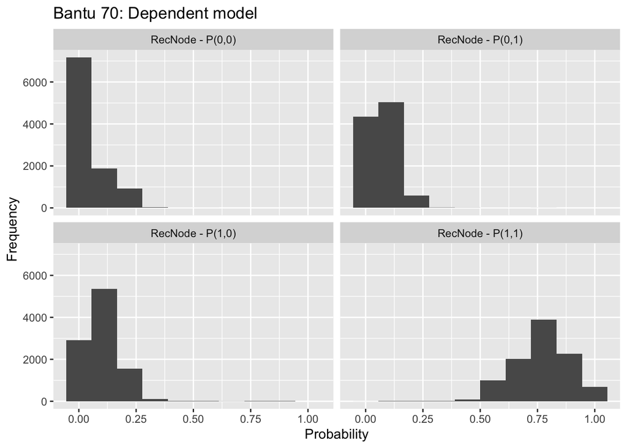

### 4.2.2 Multi-solution models

Some of the hypotheses did not converge satisfactorily despite passing the Gelman-Rubin tests. These often are switching between two possible solutions. Extending burn-in to 2332763595 iterations had no effect of convergence (this is the longest run time allowed by server constraints). Therefore we conclude that these two solutions are equally likely and we qualitatively explore the solutions here.

#### 4.2.2.1 Austronesian

###### 4.2.2.1.0.3 Eskimo and Monogamy

This hypotheses is multi-modal and running the chain longer made no decision between the two. In this instance we have two competing solutions, model one suggests it is likely that Eskimo type is the most likely ancestral state, but is split between whether monogamy was also present. Model two suggests that an Eskimo system was not the ancestral state, and neither was monogamy. Ancestral state analyses presented in this paper strongly suggests that Eskimo is very likely to be the ancestral state in Austronesia, so we take model one as the more likely model. The stepping stone sampler already prefers this model, therefore this makes no changes to our results.

## 4.3 Multiple comparisons

Since this study has numerous hypothesis tests, it is important we address the statistical problem of multiple comparisons. The multiple comparison problem says that the more hypotheses tested simultaneously, the more likely an erroneous error is to occur. There is strong debate in the literature on whether this is a problem here, but we argue that it is not.

The primary reason for this not being a problem is that all our hypotheses were set out *a priori*. They are not the result of comparing all social variables against all binary kinship terminologies, and make a tiny portion of those that are possible. All hypotheses are established in theory and many had been previously tested.

## 4.4 Phylogenetic Inertia

We were concerned that a prevalence of phylogenetic inertia was the primary reason for not finding many significant co-evolutionary relationships. That is, kinship terminologies and social organisation are so tightly tied, that we would not be able to detect a relationship using this approach. To assess how prevalent this was in our results we reviewed each hypothesis on 3 criteria; 1) What was the most likely independent ancestral state, 2) How likely was that ancestral state, and 3) How are the two variables distributed across the respective phylogenies. In an independent model (where each trait changes independent of the other) we would expect that if the ancestral state shows the presence of both traits, there is a possibility that both traits were been inherited over time, either by chance or due to a stable relationship. In both these cases, our phylogenetic approach would fail to pick up a relationship between these traits. The second criteria gives us a level of confidence in the first criteria, we assume a probability of above 0.7 indicates a high likelihood of the true ancestral state. The third criteria allows us to qualitatively review whether we think the methods are failing to detect a relationship, by visualizing the data on mirrored phylogenies. The first two criteria mean that it is plausible that two traits are ancestral, but unrelated, by looking at the distribution of traits on a tree, we can assess whether this is the case or not. Visualization also allows us to attest whether stable pairings occur later within a lineage. These plots can be found in the figures folder in the github repository. Using the three criteria above, we then decide if a hypothesis is likely to be influenced by phylogenetic inertia on a four point scale, ranging from highly likely to highly unlikely. The table below shows these judgments, and ancestral state criteria, for all hypotheses that we did not find support for. These decisions were independently decided on by each author and then conferred on the result.

Table S84: Judegments of phylogenetic inertia. The first columns shows our overall judgements. The second column shows the most likely ancestral state in an independent model of evolution, organised as [Kin terminology], [social structure]. The third column shows the probability of this state.

| hypothesis | judgement | Most likely ancestral state | Probability of ancestral state |
| --- | --- | --- | --- |
| austronesian-crow-high.polygyny | Highly unlikely | 0,0 | 0.990 |
| austronesian-crow-polygyny | Unlikely | 0,1 | 0.640 |
| austronesian-eskimo-absenceofcousinmarriage.permitted | Unlikely | 1,1 | 0.420 |
| austronesian-eskimo-absenceofcousinmarriage.preference | Highly unlikely | 1,0 | 0.810 |
| austronesian-eskimo-bi.linealdescent | Highly unlikely | 1,0 | 0.910 |
| austronesian-eskimo-neo.localresidence | Highly unlikely | 1,0 | 0.790 |
| austronesian-eskimo-nuclear.families | Likely | 1,1 | 0.740 |
| austronesian-hawaiian-absenceofcousinmarriage.permitted | Unlikely | 1,1 | 0.430 |
| austronesian-hawaiian-absenceofcousinmarriage.preference | Unlikely | 1,0 | 0.520 |
| austronesian-hawaiian-bi.linealdescent | Unlikely | 0,0 | 0.440 |
| austronesian-hawaiian-bi.localextendedfamily | Unlikely | 1,1 | 0.300 |
| austronesian-hawaiian-bi.localresidence | Highly unlikely | 1,0 | 0.500 |
| austronesian-iroquois-exogamy.unilineal.descent | Highly unlikely | 0,0 | 0.990 |
| austronesian-iroquois-high.polygyny | Highly unlikely | 0,0 | 0.990 |
| austronesian-iroquois-matri.anvunclocalresidence | Highly unlikely | 0,0 | 0.960 |
| austronesian-iroquois-polygyny | Highly unlikely | 0,1 | 0.620 |
| austronesian-iroquois-uni.linealdescent | Highly unlikely | 0,0 | 0.920 |
| bantu-crow-matri.anvunclocalresidence | Highly unlikely | 0,0 | 0.650 |
| bantu-crow-matrilineal | Highly unlikely | 0,0 | 0.680 |
| bantu-crow-matrilocal | Highly unlikely | 0,0 | 0.970 |
| bantu-crow-uni.localresidence | Highly unlikely | 0,1 | 0.950 |
| bantu-hawaiian-absenceofcousinmarriage.permitted | Highly unlikely | 0,1 | 0.879 |
| bantu-hawaiian-absenceofcousinmarriage.preference | Highly unlikely | 0,0 | 0.900 |
| bantu-hawaiian-bi.linealdescent | Highly unlikely | 0,0 | 0.890 |
| bantu-hawaiian-bi.localextendedfamily | Highly unlikely | 0,0 | 0.730 |
| bantu-hawaiian-bi.localresidence | Highly unlikely | 0,0 | 0.920 |
| bantu-iroquois-cross.cousinmarriage.preferred | Highly likely | 1,1 | 0.510 |
| bantu-iroquois-exogamy.unilineal.descent | Highly unlikely | 0,0 | 0.440 |
| bantu-iroquois-uni.linealdescent | Unlikely | 1,1 | 0.590 |
| bantu-iroquois-uni.localresidence | Likely | 1,1 | 0.500 |
| bantu-omaha-uni.localresidence | Highly unlikely | 0,1 | 0.930 |
| uto-hawaiian-absenceofcousinmarriage.permitted | Unlikely | 1,1 | 0.980 |
| uto-hawaiian-absenceofcousinmarriage.preference | Likely | 1,0 | 0.990 |
| uto-hawaiian-bi.linealdescent | Highly unlikely | 1,0 | 0.980 |
| uto-hawaiian-bi.localextendedfamily | Unlikely | 1,0 | 0.740 |
| uto-hawaiian-bi.localresidence | Unlikely | 1,0 | 0.980 |
| uto-iroquois-cross.cousinmarriage.permitted | Highly unlikely | 0,0 | 0.990 |
| uto-iroquois-cross.cousinmarriage.preferred | Highly unlikely | 0,0 | 0.990 |
| uto-iroquois-exogamy.unilineal.descent | Highly unlikely | 0,0 | 0.990 |
| uto-iroquois-high.polygyny | Highly unlikely | 0,0 | 0.990 |
| uto-iroquois-matri.anvunclocalresidence | Highly unlikely | 0,0 | 0.950 |
| uto-iroquois-uni.linealdescent | Highly unlikely | 0,0 | 0.990 |
| uto-iroquois-uni.localresidence | Highly unlikely | 0,0 | 0.490 |

# 5 References